# ANOVA test for coesao

Geiser C. Challco geiser@alumni.usp.br

- ANOVA: coesao ~ time
  - Data Preparation
  - Summary Statistics
  - ANOVA Computation
  - PairWise Computation
- ANOVA: coesao ~ time*gender + Error(id/time)
  - Data Preparation
    - Check assumptions: Identifying Outliers
    - Check assumptions: Normality Test
    - Summary Statistics
  - ANOVA Computation
  - ANOVA Computation after removing non.normal data
  - PairWise Computation
  - PairWise Computation after removing non.normal data
- ANOVA: coesao ~ time*localizacao + Error(id/time)
  - Data Preparation
    - Check assumptions: Identifying Outliers
    - Check assumptions: Normality Test
    - Summary Statistics
  - ANOVA Computation
  - ANOVA Computation after removing non.normal data
  - PairWise Computation
  - PairWise Computation after removing non.normal data
- ANOVA: coesao ~ time*regiao + Error(id/time)
  - Data Preparation
    - Check assumptions: Identifying Outliers
    - Check assumptions: Normality Test
    - Summary Statistics
  - ANOVA Computation
  - ANOVA Computation after removing non.normal data
  - PairWise Computation
  - PairWise Computation after removing non.normal data
- ANOVA: coesao ~ time*porte + Error(id/time)
  - Data Preparation
    - Check assumptions: Identifying Outliers
    - Check assumptions: Normality Test
    - Summary Statistics
  - ANOVA Computation
  - ANOVA Computation after removing non.normal data
  - PairWise Computation
  - PairWise Computation after removing non.normal data

```r
dat <- read_excel("../data/data.xlsx", sheet = "alunos_ef14")

escolas <- read_excel("../data/data.xlsx", sheet = "escolas")
edat <- merge(dat, escolas, by = "cod_escola", all.x = T)
```

# ANOVA: coesao ~ time

## Data Preparation

```r
data <- edat[,c("aluno_id","ciclo","coesao")]
data <- data[data$ciclo %in% c("Primeiro Ciclo","Segundo Ciclo","Terceiro Ciclo","Quarto Ciclo"),]
data$ciclo <- factor(data$ciclo, c("Primeiro Ciclo","Segundo Ciclo","Terceiro Ciclo","Quarto Ciclo"))
data <- unique(data)

wdat <- spread(data, ciclo, coesao)
wdat <- wdat[complete.cases(wdat),]
colnames(wdat) <- c("id","c1","c2","c3","c4")

ldat <- gather(wdat, key = time, value = coesao, c1,c2,c3,c4) %>%
  convert_as_factor(id, time)
ldat <- rshinystatistics::remove_group_data(ldat, "coesao", "time", n.limit = 30)
```

## Summary Statistics

```r
(sdat <- ldat %>% group_by(time) %>%
   get_summary_stats(coesao, type = "mean_sd"))
```

```
## # A tibble: 4 × 5
##   time  variable     n  mean    sd
##   <fct> <fct>    <dbl> <dbl> <dbl>
## 1 c1    coesao    1126  2.01 0.099
## 2 c2    coesao    1126  2.03 0.248
## 3 c3    coesao    1126  2.03 0.245
## 4 c4    coesao    1126  2.02 0.176
```

| time | variable | n | mean | sd |
| --- | --- | --- | --- | --- |
| c1 | coesao | 1126 | 2.006 | 0.099 |
| c2 | coesao | 1126 | 2.030 | 0.248 |
| c3 | coesao | 1126 | 2.028 | 0.245 |
| c4 | coesao | 1126 | 2.016 | 0.176 |

## ANOVA Computation

```r
(res.aov <- anova_test(ldat, dv = coesao, wid = id, within = time))
```

```
## ANOVA Table (type III tests)
##
## $ANOVA
##   Effect DFn  DFd     F     p p<.05   ges
## 1   time   3 3375 3.743 0.011     * 0.002
##
## $`Mauchly's Test for Sphericity`
##   Effect     W                                                                        p p<.05
## 1   time 0.749 0.0000000000000000000000000000000000000000000000000000000000000000000418     *
##
## $`Sphericity Corrections`
##   Effect   GGe        DF[GG] p[GG] p[GG]<.05   HFe        DF[HF] p[HF] p[HF]<.05
## 1   time 0.874 2.62, 2948.59 0.014         * 0.876 2.63, 2956.09 0.014         *
```

| Effect | DFn | DFd | F | p | p<.05 | ges |
| --- | --- | --- | --- | --- | --- | --- |
| time | 3 | 3375 | 3.743 | 0.011 | * | 0.002 |

| Effect | W | p | p<.05 |
| --- | --- | --- | --- |
| time | 0.749 | 0 | * |

| Effect | GGe | DF[GG] | p[GG] | p[GG]<.05 | HFe | DF[HF] | p[HF] | p[HF]<.05 |
| --- | --- | --- | --- | --- | --- | --- | --- | --- |
| time | 0.874 | 2.62, 2948.59 | 0.014 | * | 0.876 | 2.63, 2956.09 | 0.014 | * |

## PairWise Computation

```r
(pwc <- ldat %>% emmeans_test(coesao ~ time, detailed = T, p.adjust.method = "bonferroni"))
```

```
## # A tibble: 6 × 14
##   term  .y.    group1 group2 null.value estimate      se    df conf.low conf.high statistic       p
## * <chr> <chr>  <chr>  <chr>       <dbl>    <dbl>   <dbl> <dbl>    <dbl>     <dbl>     <dbl>   <dbl>
## 1 time  coesao c1     c2              0 -0.0240  0.00849  4500 -0.0406   -0.00734    -2.83  0.00474
## 2 time  coesao c1     c3              0 -0.0222  0.00849  4500 -0.0388   -0.00556    -2.62  0.00892
## 3 time  coesao c1     c4              0 -0.0102  0.00849  4500 -0.0269    0.00642    -1.20  0.229
## 4 time  coesao c2     c3              0  0.00178 0.00849  4500 -0.0149    0.0184      0.209 0.834
## 5 time  coesao c2     c4              0  0.0138  0.00849  4500 -0.00287   0.0304      1.62  0.105
## 6 time  coesao c3     c4              0  0.0120  0.00849  4500 -0.00465   0.0286      1.41  0.158
## # ℹ 2 more variables: p.adj <dbl>, p.adj.signif <chr>
```

| term | .y. | group1 | group2 | null.value | estimate | se | df | conf.low | conf.high | statistic | p | p.adj | p.adj.signif |
| --- | --- | --- | --- | --- | --- | --- | --- | --- | --- | --- | --- | --- | --- |
| time | coesao | c1 | c2 | 0 | -0.024 | 0.008 | 4500 | -0.041 | -0.007 | -2.825 | 0.005 | 0.028 | * |
| time | coesao | c1 | c3 | 0 | -0.022 | 0.008 | 4500 | -0.039 | -0.006 | -2.616 | 0.009 | 0.054 | ns |
| time | coesao | c1 | c4 | 0 | -0.010 | 0.008 | 4500 | -0.027 | 0.006 | -1.203 | 0.229 | 1.000 | ns |
| time | coesao | c2 | c3 | 0 | 0.002 | 0.008 | 4500 | -0.015 | 0.018 | 0.209 | 0.834 | 1.000 | ns |
| time | coesao | c2 | c4 | 0 | 0.014 | 0.008 | 4500 | -0.003 | 0.030 | 1.622 | 0.105 | 0.629 | ns |
| time | coesao | c3 | c4 | 0 | 0.012 | 0.008 | 4500 | -0.005 | 0.029 | 1.413 | 0.158 | 0.947 | ns |

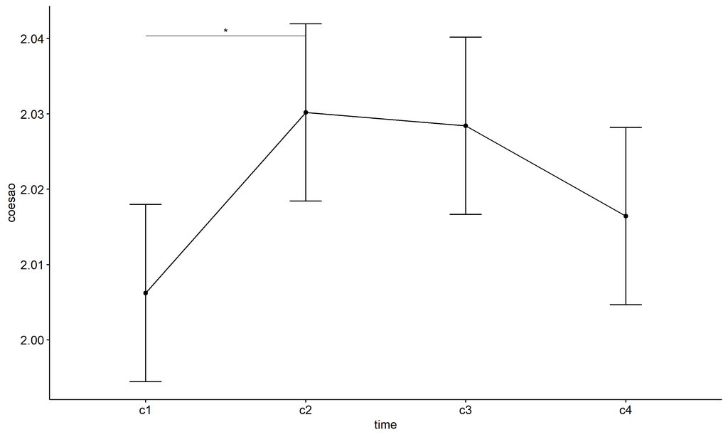

```r
pwc <- add_xy_position(pwc, x = "time", fun = "mean_se")
ggline(get_emmeans(pwc), x = "time", y = "emmean", ylab = "coesao") +
  geom_errorbar(aes(ymin = conf.low, ymax = conf.high), width = 0.2) +
  stat_pvalue_manual(pwc, hide.ns = T, tip.length = F)
```

# ANOVA: coesao ~ time*gender + Error(id/time)

## Data Preparation

```r
data <- edat[,c("aluno_id","gender","ciclo","coesao")]
data <- data[data$ciclo %in% c("Primeiro Ciclo","Segundo Ciclo","Terceiro Ciclo","Quarto Ciclo"),]
data$ciclo <- factor(data$ciclo, c("Primeiro Ciclo","Segundo Ciclo","Terceiro Ciclo","Quarto Ciclo"))
data <- unique(data)

wdat <- spread(data, ciclo, coesao)
wdat <- wdat[complete.cases(wdat),]
colnames(wdat) <- c("id","gender","c1","c2","c3","c4")

ldat <- gather(wdat, key = time, value = coesao, c1,c2,c3,c4) %>%
  convert_as_factor(id, time)
ldat <- remove_group_data(ldat, "coesao", c("time", "gender"), n.limit = 30)
ldat$gender <- factor(ldat$gender, sort(unique(ldat$gender)))
```

### Check assumptions: Identifying Outliers

```r
outliers <- identify_outliers(group_by(ldat, time, gender), coesao)
(outliers <- outliers[outliers$is.extreme == T,])
```

```
## # A tibble: 49 × 6
##    gender time  id                   coesao is.outlier is.extreme
##    <fct>  <fct> <fct>                 <dbl> <lgl>      <lgl>
##  1 Female c1    IZ2Xmfi9jueckwdzfkiG      3 TRUE       TRUE
##  2 Male   c1    JRyGpNQA6mOEl1nzl1af      3 TRUE       TRUE
##  3 Male   c1    Kaj54imycuE0bbwH7xlD      3 TRUE       TRUE
##  4 Male   c1    W8iXxSmW48zvfJyikMZb      4 TRUE       TRUE
##  5 Male   c1    Y7HozU436KQ0wqdBGugu      4 TRUE       TRUE
##  6 Female c2    0mGtUd2Axg2fjQmYZ4CC      3 TRUE       TRUE
##  7 Female c2    EqNpFnKTbLOWH4nmuu6d      4 TRUE       TRUE
##  8 Female c2    G4NIt8gEc7nfeQ9k2OkL      4 TRUE       TRUE
##  9 Female c2    i5EZ8Ck9IgDueyMbw55v      3 TRUE       TRUE
## 10 Female c2    oGUJyWRMYYbF9PNegJZh      4 TRUE       TRUE
## # ℹ 39 more rows
```

| gender | time | id | coesao | is.outlier | is.extreme |
| --- | --- | --- | --- | --- | --- |
| Female | c1 | IZ2Xmfi9jueckwdzfkiG | 3.0 | TRUE | TRUE |
| Male | c1 | JRyGpNQA6mOEl1nzl1af | 3.0 | TRUE | TRUE |
| Male | c1 | Kaj54imycuE0bbwH7xlD | 3.0 | TRUE | TRUE |
| Male | c1 | W8iXxSmW48zvfJyikMZb | 4.0 | TRUE | TRUE |
| Male | c1 | Y7HozU436KQ0wqdBGugu | 4.0 | TRUE | TRUE |
| Female | c2 | 0mGtUd2Axg2fjQmYZ4CC | 3.0 | TRUE | TRUE |
| Female | c2 | EqNpFnKTbLOWH4nmuu6d | 4.0 | TRUE | TRUE |
| Female | c2 | G4NIt8gEc7nfeQ9k2OkL | 4.0 | TRUE | TRUE |
| Female | c2 | i5EZ8Ck9IgDueyMbw55v | 3.0 | TRUE | TRUE |
| Female | c2 | oGUJyWRMYYbF9PNegJZh | 4.0 | TRUE | TRUE |
| Female | c2 | xk7eC5haTYuFQaJovsBZ | 4.0 | TRUE | TRUE |
| Female | c2 | xQIlV1qQiNpzi4Bna9Ut | 4.0 | TRUE | TRUE |
| Female | c2 | YTYFFWzK4C7ejf1X1TUB | 4.0 | TRUE | TRUE |
| Male | c2 | cuknOzzwN4oCRum5U5ph | 5.0 | TRUE | TRUE |
| Male | c2 | G7bqQeqXmsQ3kiJNeYlz | 3.0 | TRUE | TRUE |
| Male | c2 | HsQF2J0r79mHSWNe4l6n | 4.0 | TRUE | TRUE |
| Male | c2 | j31LU8Xwm0EQ7Mihkhjj | 4.0 | TRUE | TRUE |
| Male | c2 | qyt5dpIrCcmnZfDJIazf | 4.0 | TRUE | TRUE |
| Male | c2 | W8iXxSmW48zvfJyikMZb | 4.0 | TRUE | TRUE |
| Male | c2 | wgOGhRdGeAbGeHUAguQ5 | 5.0 | TRUE | TRUE |
| Male | c2 | wQnhAn0Gfye5OP5zaTgh | 4.0 | TRUE | TRUE |
| Male | c2 | wuumviqqlrNK6QzeoJPr | 4.0 | TRUE | TRUE |
| Male | c2 | XxtCdGkKAnQOx88fyxk4 | 3.0 | TRUE | TRUE |
| Female | c3 | 6bEKmKQpOuvY6PSQvzqj | 4.0 | TRUE | TRUE |
| Female | c3 | CCVIt7MPeYMUOCCyBxPh | 4.0 | TRUE | TRUE |
| Female | c3 | i5EZ8Ck9IgDueyMbw55v | 5.0 | TRUE | TRUE |
| Female | c3 | m5yRlxfIj73j4ossfTOB | 5.0 | TRUE | TRUE |
| Female | c3 | OvwAQTWkdj8SYpPS8dgn | 4.0 | TRUE | TRUE |
| Female | c3 | u65Z834z75LDIy0slvaX | 5.0 | TRUE | TRUE |
| Female | c3 | vaOhaNww5ga5d9G6Cftj | 4.0 | TRUE | TRUE |
| Female | c3 | xk7eC5haTYuFQaJovsBZ | 4.0 | TRUE | TRUE |
| Male | c3 | E3u63riyMFS8A2cNBnvC | 3.0 | TRUE | TRUE |
| Male | c3 | EtUjsyq1GNevicwMDXlw | 3.5 | TRUE | TRUE |
| Male | c3 | FkJFrnPezc8Ng4SSMx1z | 4.0 | TRUE | TRUE |
| Male | c3 | GN5vxU0haHKd9W22JGyk | 4.0 | TRUE | TRUE |
| Male | c3 | HsQF2J0r79mHSWNe4l6n | 3.0 | TRUE | TRUE |
| Male | c3 | j31LU8Xwm0EQ7Mihkhjj | 4.0 | TRUE | TRUE |
| Male | c3 | QAyx2z41ILLaMN0o7pjc | 3.0 | TRUE | TRUE |
| Male | c3 | TKvc4Eu2XaDXYPxuS7Qn | 4.0 | TRUE | TRUE |
| Female | c4 | 6bEKmKQpOuvY6PSQvzqj | 4.0 | TRUE | TRUE |
| Female | c4 | DP1fbT1lGhLiBnOFILLi | 4.0 | TRUE | TRUE |
| Female | c4 | fgNBRPWfCa0TP4bDO8d2 | 4.0 | TRUE | TRUE |
| Female | c4 | jVbbowshsqkUpPuGSIMu | 4.0 | TRUE | TRUE |
| Female | c4 | N7zTvCPK4nAUgH9eo3hg | 4.0 | TRUE | TRUE |
| Female | c4 | tVMilOzYDlVoWwNezYUi | 4.0 | TRUE | TRUE |
| Female | c4 | VRWfIoYUFgdA8nGO5bpD | 4.0 | TRUE | TRUE |
| Female | c4 | zq67YfRtJ2g4hWPYAfkU | 3.0 | TRUE | TRUE |
| Male | c4 | 3DdYC9Dpykr9Mtg6YR91 | 4.0 | TRUE | TRUE |
| Male | c4 | IMHqraVHK59KiF08zsGi | 3.5 | TRUE | TRUE |

### Check assumptions: Normality Test

```r
(normality.df <- normality.test.per.groups(ldat, "coesao", c("time", "gender")))
```

```
##      var variable time gender   n skewness kurtosis symmetry statistic     method p p.signif
## 1 coesao   coesao   c1 Female 552 0.000000  0.00000 few data        NA       <NA> 1     <NA>
## 2 coesao   coesao   c1   Male 513 0.000000  0.00000 few data        NA       <NA> 1     <NA>
## 3 coesao   coesao   c2 Female 552 0.000000  0.00000 few data        NA       <NA> 1     <NA>
## 4 coesao   coesao   c2   Male 513 7.861704 63.79694       NO  737.6279 D'Agostino 0     ****
## 5 coesao   coesao   c3 Female 552 0.000000  0.00000 few data        NA       <NA> 1     <NA>
## 6 coesao   coesao   c3   Male 513 8.678249 76.66803       NO  782.9274 D'Agostino 0     ****
## 7 coesao   coesao   c4 Female 552 0.000000  0.00000 few data        NA       <NA> 1     <NA>
## 8 coesao   coesao   c4   Male 513 0.000000  0.00000 few data        NA       <NA> 1     <NA>
##   normality
## 1        NO
## 2        NO
## 3        NO
## 4         -
## 5        NO
## 6         -
## 7        NO
## 8        NO
```

| var | variable | time | gender | n | skewness | kurtosis | symmetry | statistic | method | p | p.signif | normality |
| --- | --- | --- | --- | --- | --- | --- | --- | --- | --- | --- | --- | --- |
| coesao | coesao | c1 | Female | 552 | 0.000 | 0.000 | few data | NA | NA | 1 | NA | NO |
| coesao | coesao | c1 | Male | 513 | 0.000 | 0.000 | few data | NA | NA | 1 | NA | NO |
| coesao | coesao | c2 | Female | 552 | 0.000 | 0.000 | few data | NA | NA | 1 | NA | NO |
| coesao | coesao | c2 | Male | 513 | 7.862 | 63.797 | NO | 737.628 | D’Agostino | 0 | **** | - |
| coesao | coesao | c3 | Female | 552 | 0.000 | 0.000 | few data | NA | NA | 1 | NA | NO |
| coesao | coesao | c3 | Male | 513 | 8.678 | 76.668 | NO | 782.927 | D’Agostino | 0 | **** | - |
| coesao | coesao | c4 | Female | 552 | 0.000 | 0.000 | few data | NA | NA | 1 | NA | NO |
| coesao | coesao | c4 | Male | 513 | 0.000 | 0.000 | few data | NA | NA | 1 | NA | NO |

```r
(non.ids <- unique(do.call(
  c, lapply(which(normality.df$normality == 'NO'), FUN = function(i) {
  idx = which(ldat$time == normality.df$time[i] &
                ldat$gender == normality.df$gender[i])
  getNonNormal(ldat$"coesao"[idx], ldat$id[idx])
}))))
```

```r
if (length(non.ids) > 0)
  ldat2 <- ldat[!ldat$id %in% non.ids,]
```

### Summary Statistics

```r
(sdat <- ldat %>% group_by(time, gender) %>%
   get_summary_stats(coesao, type = "mean_sd"))
```

```
## # A tibble: 8 × 6
##   gender time  variable     n  mean    sd
##   <fct>  <fct> <fct>    <dbl> <dbl> <dbl>
## 1 Female c1    coesao     552  2.00 0.043
## 2 Male   c1    coesao     513  2.01 0.139
## 3 Female c2    coesao     552  2.02 0.216
## 4 Male   c2    coesao     513  2.04 0.291
## 5 Female c3    coesao     552  2.03 0.29
## 6 Male   c3    coesao     513  2.02 0.202
## 7 Female c4    coesao     552  2.03 0.228
## 8 Male   c4    coesao     513  2.01 0.11
```

| gender | time | variable | n | mean | sd |
| --- | --- | --- | --- | --- | --- |
| Female | c1 | coesao | 552 | 2.002 | 0.043 |
| Male | c1 | coesao | 513 | 2.012 | 0.139 |
| Female | c2 | coesao | 552 | 2.025 | 0.216 |
| Male | c2 | coesao | 513 | 2.039 | 0.291 |
| Female | c3 | coesao | 552 | 2.034 | 0.290 |
| Male | c3 | coesao | 513 | 2.024 | 0.202 |
| Female | c4 | coesao | 552 | 2.027 | 0.228 |
| Male | c4 | coesao | 513 | 2.007 | 0.110 |

```r
if (length(non.ids) > 0)
  (sdat <- ldat2 %>% group_by(time, gender) %>%
      get_summary_stats(coesao, type = "mean_sd"))
```

| gender | time | variable | n | mean | sd |
| --- | --- | --- | --- | --- | --- |
| Female | c1 | coesao | 552 | 2.002 | 0.043 |
| Male | c1 | coesao | 513 | 2.012 | 0.139 |
| Female | c2 | coesao | 552 | 2.025 | 0.216 |
| Male | c2 | coesao | 513 | 2.039 | 0.291 |
| Female | c3 | coesao | 552 | 2.034 | 0.290 |
| Male | c3 | coesao | 513 | 2.024 | 0.202 |
| Female | c4 | coesao | 552 | 2.027 | 0.228 |
| Male | c4 | coesao | 513 | 2.007 | 0.110 |

## ANOVA Computation

```r
(res.aov <- anova_test(ldat, dv = coesao, wid = id, between = gender, within = time))
```

```
## ANOVA Table (type III tests)
##
## $ANOVA
##        Effect DFn  DFd     F     p p<.05       ges
## 1      gender   1 1063 0.061 0.804       0.0000174
## 2        time   3 3189 3.678 0.012     * 0.0020000
## 3 gender:time   3 3189 1.748 0.155       0.0010000
##
## $`Mauchly's Test for Sphericity`
##        Effect     W                                                                    p p<.05
## 1        time 0.748 0.000000000000000000000000000000000000000000000000000000000000000227     *
## 2 gender:time 0.748 0.000000000000000000000000000000000000000000000000000000000000000227     *
##
## $`Sphericity Corrections`
##        Effect   GGe        DF[GG] p[GG] p[GG]<.05   HFe        DF[HF] p[HF] p[HF]<.05
## 1        time 0.874 2.62, 2785.67 0.016         * 0.876 2.63, 2793.18 0.016         *
## 2 gender:time 0.874 2.62, 2785.67 0.162           0.876 2.63, 2793.18 0.162
```

| Effect | DFn | DFd | F | p | p<.05 | ges |
| --- | --- | --- | --- | --- | --- | --- |
| gender | 1 | 1063 | 0.061 | 0.804 |  | 0.000 |
| time | 3 | 3189 | 3.678 | 0.012 | * | 0.002 |
| gender:time | 3 | 3189 | 1.748 | 0.155 |  | 0.001 |

| Effect | W | p | p<.05 |
| --- | --- | --- | --- |
| time | 0.748 | 0 | * |
| gender:time | 0.748 | 0 | * |

| Effect | GGe | DF[GG] | p[GG] | p[GG]<.05 | HFe | DF[HF] | p[HF] | p[HF]<.05 |
| --- | --- | --- | --- | --- | --- | --- | --- | --- |
| time | 0.874 | 2.62, 2785.67 | 0.016 | * | 0.876 | 2.63, 2793.18 | 0.016 | * |
| gender:time | 0.874 | 2.62, 2785.67 | 0.162 |  | 0.876 | 2.63, 2793.18 | 0.162 |  |

## ANOVA Computation after removing non.normal data

```r
if (length(non.ids) > 0)
  (res.aov2 <- anova_test(ldat2, dv = coesao, wid = id, between = gender , within = time))
```

## PairWise Computation

```r
(pwc <- ldat %>% group_by(time) %>%
   emmeans_test(coesao ~ gender, detailed = T, p.adjust.method = "bonferroni"))
```

```
## # A tibble: 4 × 15
##   time  term  .y.   group1 group2 null.value estimate     se    df conf.low conf.high statistic     p
## * <fct> <chr> <chr> <chr>  <chr>       <dbl>    <dbl>  <dbl> <dbl>    <dbl>     <dbl>     <dbl> <dbl>
## 1 c1    gend… coes… Female Male            0 -0.00988 0.0127  4252 -0.0348     0.0150    -0.779 0.436
## 2 c2    gend… coes… Female Male            0 -0.0136  0.0127  4252 -0.0385     0.0112    -1.07  0.283
## 3 c3    gend… coes… Female Male            0  0.0101  0.0127  4252 -0.0148     0.0349     0.793 0.428
## 4 c4    gend… coes… Female Male            0  0.0204  0.0127  4252 -0.00452    0.0452     1.60  0.109
## # ℹ 2 more variables: p.adj <dbl>, p.adj.signif <chr>
```

| time | term | .y. | group1 | group2 | null.value | estimate | se | df | conf.low | conf.high | statistic | p | p.adj | p.adj.signif |
| --- | --- | --- | --- | --- | --- | --- | --- | --- | --- | --- | --- | --- | --- | --- |
| c1 | gender | coesao | Female | Male | 0 | -0.010 | 0.013 | 4252 | -0.035 | 0.015 | -0.779 | 0.436 | 0.436 | ns |
| c2 | gender | coesao | Female | Male | 0 | -0.014 | 0.013 | 4252 | -0.038 | 0.011 | -1.074 | 0.283 | 0.283 | ns |
| c3 | gender | coesao | Female | Male | 0 | 0.010 | 0.013 | 4252 | -0.015 | 0.035 | 0.793 | 0.428 | 0.428 | ns |
| c4 | gender | coesao | Female | Male | 0 | 0.020 | 0.013 | 4252 | -0.005 | 0.045 | 1.604 | 0.109 | 0.109 | ns |

```r
(emms <- get_emmeans(pwc))
```

```
## # A tibble: 8 × 8
##   time  gender emmean      se    df conf.low conf.high method
##   <fct> <fct>   <dbl>   <dbl> <dbl>    <dbl>     <dbl> <chr>
## 1 c1    Female   2.00 0.00880  4252     1.98      2.02 Emmeans test
## 2 c1    Male     2.01 0.00913  4252     1.99      2.03 Emmeans test
## 3 c2    Female   2.03 0.00880  4252     2.01      2.04 Emmeans test
## 4 c2    Male     2.04 0.00913  4252     2.02      2.06 Emmeans test
## 5 c3    Female   2.03 0.00880  4252     2.02      2.05 Emmeans test
## 6 c3    Male     2.02 0.00913  4252     2.01      2.04 Emmeans test
## 7 c4    Female   2.03 0.00880  4252     2.01      2.04 Emmeans test
## 8 c4    Male     2.01 0.00913  4252     1.99      2.02 Emmeans test
```

| time | gender | emmean | se | df | conf.low | conf.high | method |
| --- | --- | --- | --- | --- | --- | --- | --- |
| c1 | Female | 2.002 | 0.009 | 4252 | 1.985 | 2.019 | Emmeans test |
| c1 | Male | 2.012 | 0.009 | 4252 | 1.994 | 2.030 | Emmeans test |
| c2 | Female | 2.025 | 0.009 | 4252 | 2.008 | 2.043 | Emmeans test |
| c2 | Male | 2.039 | 0.009 | 4252 | 2.021 | 2.057 | Emmeans test |
| c3 | Female | 2.034 | 0.009 | 4252 | 2.017 | 2.052 | Emmeans test |
| c3 | Male | 2.024 | 0.009 | 4252 | 2.006 | 2.042 | Emmeans test |
| c4 | Female | 2.027 | 0.009 | 4252 | 2.010 | 2.044 | Emmeans test |
| c4 | Male | 2.007 | 0.009 | 4252 | 1.989 | 2.025 | Emmeans test |

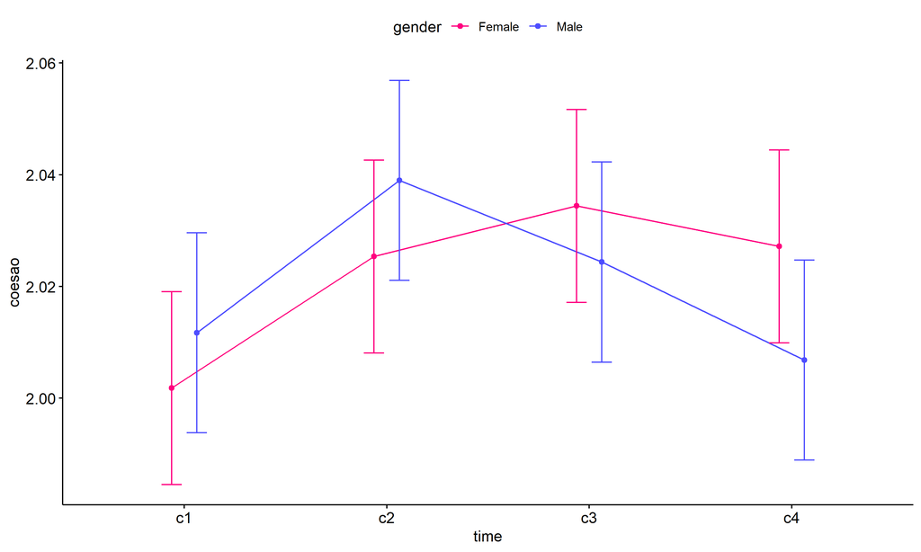

```r
pwc <- add_xy_position(pwc, x = "time", fun = "mean_se", dodge = 0.25)
pd <- position_dodge(width = 0.25)
ggline(emms, x = "time", y = "emmean", color = "gender",
       palette = c("#FF007F","#4D4DFF"),
       position = pd, ylab = "coesao") +
  geom_errorbar(aes(ymin = conf.low, ymax = conf.high, color = gender),
                position = pd, width = 0.2) +
  stat_pvalue_manual(pwc, hide.ns = T, tip.length = F, linetype = 1)
```

```r
(pwc <- ldat %>% group_by(gender) %>%
    emmeans_test(coesao ~ time, detailed = T, p.adjust.method = "bonferroni"))
```

```
## # A tibble: 12 × 15
##    gender term  .y.    group1 group2 null.value estimate     se    df conf.low conf.high statistic
##  * <fct>  <chr> <chr>  <chr>  <chr>       <dbl>    <dbl>  <dbl> <dbl>    <dbl>     <dbl>     <dbl>
##  1 Female time  coesao c1     c2              0 -0.0236  0.0124  4252 -0.0480   0.000858    -1.89
##  2 Female time  coesao c1     c3              0 -0.0326  0.0124  4252 -0.0570  -0.00820     -2.62
##  3 Female time  coesao c1     c4              0 -0.0254  0.0124  4252 -0.0498  -0.000954    -2.04
##  4 Female time  coesao c2     c3              0 -0.00906 0.0124  4252 -0.0335   0.0154      -0.728
##  5 Female time  coesao c2     c4              0 -0.00181 0.0124  4252 -0.0262   0.0226      -0.146
##  6 Female time  coesao c3     c4              0  0.00725 0.0124  4252 -0.0172   0.0317       0.582
##  7 Male   time  coesao c1     c2              0 -0.0273  0.0129  4252 -0.0526  -0.00197     -2.11
##  8 Male   time  coesao c1     c3              0 -0.0127  0.0129  4252 -0.0380   0.0126      -0.981
##  9 Male   time  coesao c1     c4              0  0.00487 0.0129  4252 -0.0204   0.0302       0.377
## 10 Male   time  coesao c2     c3              0  0.0146  0.0129  4252 -0.0107   0.0399       1.13
## 11 Male   time  coesao c2     c4              0  0.0322  0.0129  4252  0.00684  0.0575       2.49
## 12 Male   time  coesao c3     c4              0  0.0175  0.0129  4252 -0.00778  0.0429       1.36
## # ℹ 3 more variables: p <dbl>, p.adj <dbl>, p.adj.signif <chr>
```

| gender | term | .y. | group1 | group2 | null.value | estimate | se | df | conf.low | conf.high | statistic | p | p.adj | p.adj.signif |
| --- | --- | --- | --- | --- | --- | --- | --- | --- | --- | --- | --- | --- | --- | --- |
| Female | time | coesao | c1 | c2 | 0 | -0.024 | 0.012 | 4252 | -0.048 | 0.001 | -1.892 | 0.059 | 0.352 | ns |
| Female | time | coesao | c1 | c3 | 0 | -0.033 | 0.012 | 4252 | -0.057 | -0.008 | -2.619 | 0.009 | 0.053 | ns |
| Female | time | coesao | c1 | c4 | 0 | -0.025 | 0.012 | 4252 | -0.050 | -0.001 | -2.037 | 0.042 | 0.250 | ns |
| Female | time | coesao | c2 | c3 | 0 | -0.009 | 0.012 | 4252 | -0.033 | 0.015 | -0.728 | 0.467 | 1.000 | ns |
| Female | time | coesao | c2 | c4 | 0 | -0.002 | 0.012 | 4252 | -0.026 | 0.023 | -0.146 | 0.884 | 1.000 | ns |
| Female | time | coesao | c3 | c4 | 0 | 0.007 | 0.012 | 4252 | -0.017 | 0.032 | 0.582 | 0.561 | 1.000 | ns |
| Male | time | coesao | c1 | c2 | 0 | -0.027 | 0.013 | 4252 | -0.053 | -0.002 | -2.113 | 0.035 | 0.208 | ns |
| Male | time | coesao | c1 | c3 | 0 | -0.013 | 0.013 | 4252 | -0.038 | 0.013 | -0.981 | 0.327 | 1.000 | ns |
| Male | time | coesao | c1 | c4 | 0 | 0.005 | 0.013 | 4252 | -0.020 | 0.030 | 0.377 | 0.706 | 1.000 | ns |
| Male | time | coesao | c2 | c3 | 0 | 0.015 | 0.013 | 4252 | -0.011 | 0.040 | 1.132 | 0.258 | 1.000 | ns |
| Male | time | coesao | c2 | c4 | 0 | 0.032 | 0.013 | 4252 | 0.007 | 0.057 | 2.491 | 0.013 | 0.077 | ns |
| Male | time | coesao | c3 | c4 | 0 | 0.018 | 0.013 | 4252 | -0.008 | 0.043 | 1.358 | 0.174 | 1.000 | ns |

```r
(emms <- get_emmeans(pwc))
```

```
## # A tibble: 8 × 8
##   gender time  emmean      se    df conf.low conf.high method
##   <fct>  <fct>  <dbl>   <dbl> <dbl>    <dbl>     <dbl> <chr>
## 1 Female c1      2.00 0.00880  4252     1.98      2.02 Emmeans test
## 2 Female c2      2.03 0.00880  4252     2.01      2.04 Emmeans test
## 3 Female c3      2.03 0.00880  4252     2.02      2.05 Emmeans test
## 4 Female c4      2.03 0.00880  4252     2.01      2.04 Emmeans test
## 5 Male   c1      2.01 0.00913  4252     1.99      2.03 Emmeans test
## 6 Male   c2      2.04 0.00913  4252     2.02      2.06 Emmeans test
## 7 Male   c3      2.02 0.00913  4252     2.01      2.04 Emmeans test
## 8 Male   c4      2.01 0.00913  4252     1.99      2.02 Emmeans test
```

| gender | time | emmean | se | df | conf.low | conf.high | method |
| --- | --- | --- | --- | --- | --- | --- | --- |
| Female | c1 | 2.002 | 0.009 | 4252 | 1.985 | 2.019 | Emmeans test |
| Female | c2 | 2.025 | 0.009 | 4252 | 2.008 | 2.043 | Emmeans test |
| Female | c3 | 2.034 | 0.009 | 4252 | 2.017 | 2.052 | Emmeans test |
| Female | c4 | 2.027 | 0.009 | 4252 | 2.010 | 2.044 | Emmeans test |
| Male | c1 | 2.012 | 0.009 | 4252 | 1.994 | 2.030 | Emmeans test |
| Male | c2 | 2.039 | 0.009 | 4252 | 2.021 | 2.057 | Emmeans test |
| Male | c3 | 2.024 | 0.009 | 4252 | 2.006 | 2.042 | Emmeans test |
| Male | c4 | 2.007 | 0.009 | 4252 | 1.989 | 2.025 | Emmeans test |

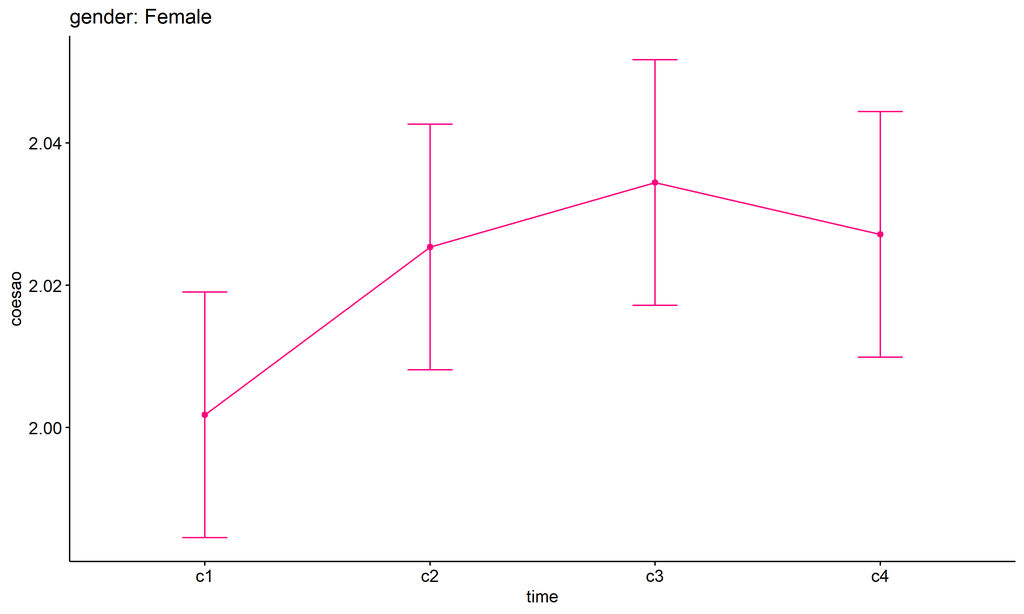

```r
emms.gg <- emms[which(emms$gender == "Female"),]
if (nrow(emms.gg) > 0)
  ggline(emms.gg, x = "time", y = "emmean", color = "#FF007F", ylab = "coesao") +
    geom_errorbar(aes(ymin = conf.low, ymax = conf.high),
                  width = 0.2, color = "#FF007F") +
    stat_pvalue_manual(
      add_xy_position(pwc[which(pwc$gender == "Female"),],
                      x = "time", fun = "mean_se"),
      hide.ns = T, color = "#FF007F", tip.length = F) +
    labs(title = "gender: Female")+
    theme(legend.text = element_blank())
```

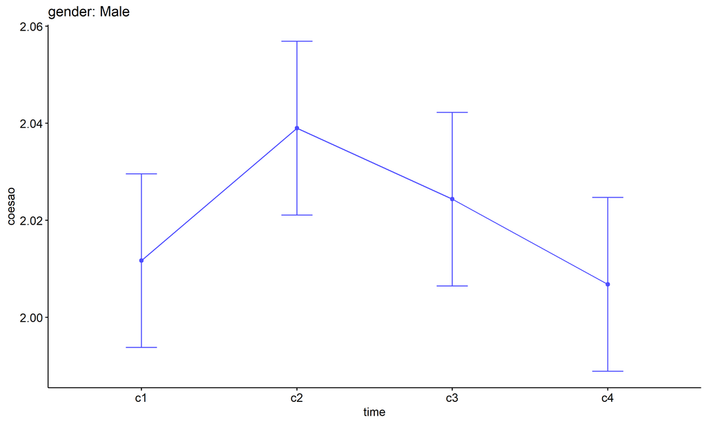

```r
emms.gg <- emms[which(emms$gender == "Male"),]
if (nrow(emms.gg) > 0)
  ggline(emms.gg, x = "time", y = "emmean", color = "#4D4DFF", ylab = "coesao") +
    geom_errorbar(aes(ymin = conf.low, ymax = conf.high),
                  width = 0.2, color = "#4D4DFF") +
    stat_pvalue_manual(
      add_xy_position(pwc[which(pwc$gender == "Male"),],
                      x = "time", fun = "mean_se"),
      hide.ns = T, color = "#4D4DFF", tip.length = F) +
    labs(title = "gender: Male")+
    theme(legend.text = element_blank())
```

## PairWise Computation after removing non.normal data

```r
if (length(non.ids) > 0)
  (pwc2 <- ldat2 %>% group_by(time) %>%
     emmeans_test(coesao ~ gender, detailed = T, p.adjust.method = "bonferroni"))
```

```r
if (length(non.ids) > 0)
  (emms2 <- get_emmeans(pwc2))
```

```r
if (length(non.ids) > 0) {
  pwc2 <- add_xy_position(pwc2, x = "time", fun = "mean_se", dodge = 0.25)
  pd2 <- position_dodge(width = 0.25)

  ggline(emms2, x = "time", y = "emmean", color = "gender",
         palette = c("#FF007F","#4D4DFF"),
         position = pd, ylab = "coesao") +
    geom_errorbar(aes(ymin = conf.low, ymax = conf.high, color = gender),
                position = pd, width = 0.2) +
    stat_pvalue_manual(pwc2, hide.ns = T, tip.length = F, linetype = 1)
}
```

```r
if (length(non.ids) > 0)
  (pwc2 <- ldat2 %>% group_by(gender) %>%
     emmeans_test(coesao ~ time, detailed = T, p.adjust.method = "bonferroni"))
```

```r
if (length(non.ids) > 0)
  (emms2 <- get_emmeans(pwc2))
```

```r
if (length(non.ids) > 0) {
  emms.gg <- emms2[which(emms2$gender == "Female"),]
  if (nrow(emms.gg) > 0)
    ggline(emms.gg, x = "time", y = "emmean", color = "#FF007F", ylab = "coesao") +
    geom_errorbar(aes(ymin = conf.low, ymax = conf.high),
                  width = 0.2, color = "#FF007F") +
    stat_pvalue_manual(
      add_xy_position(pwc[which(pwc$gender == "Female"),],
                      x = "time", fun = "mean_se"),
      hide.ns = T, color = "#FF007F", tip.length = F) +
    labs(title = "gender: Female") +
    theme(legend.text = element_blank())
}
```

```r
if (length(non.ids) > 0) {
  emms.gg <- emms2[which(emms2$gender == "Male"),]
  if (nrow(emms.gg) > 0)
    ggline(emms.gg, x = "time", y = "emmean", color = "#4D4DFF", ylab = "coesao") +
    geom_errorbar(aes(ymin = conf.low, ymax = conf.high),
                  width = 0.2, color = "#4D4DFF") +
    stat_pvalue_manual(
      add_xy_position(pwc[which(pwc$gender == "Male"),],
                      x = "time", fun = "mean_se"),
      hide.ns = T, color = "#4D4DFF", tip.length = F) +
    labs(title = "gender: Male") +
    theme(legend.text = element_blank())
}
```

# ANOVA: coesao ~ time*localizacao + Error(id/time)

## Data Preparation

```r
data <- edat[,c("aluno_id","localizacao","ciclo","coesao")]
data <- data[data$ciclo %in% c("Primeiro Ciclo","Segundo Ciclo","Terceiro Ciclo","Quarto Ciclo"),]
data$ciclo <- factor(data$ciclo, c("Primeiro Ciclo","Segundo Ciclo","Terceiro Ciclo","Quarto Ciclo"))
data <- unique(data)

wdat <- spread(data, ciclo, coesao)
wdat <- wdat[complete.cases(wdat),]
colnames(wdat) <- c("id","localizacao","c1","c2","c3","c4")

ldat <- gather(wdat, key = time, value = coesao, c1,c2,c3,c4) %>%
  convert_as_factor(id, time)
ldat <- remove_group_data(ldat, "coesao", c("time", "localizacao"), n.limit = 30)
ldat$localizacao <- factor(ldat$localizacao, sort(unique(ldat$localizacao)))
```

### Check assumptions: Identifying Outliers

```r
outliers <- identify_outliers(group_by(ldat, time, localizacao), coesao)
(outliers <- outliers[outliers$is.extreme == T,])
```

```
## # A tibble: 50 × 6
##    localizacao time  id                   coesao is.outlier is.extreme
##    <fct>       <fct> <fct>                 <dbl> <lgl>      <lgl>
##  1 Rural       c1    Kaj54imycuE0bbwH7xlD      3 TRUE       TRUE
##  2 Urbana      c1    IZ2Xmfi9jueckwdzfkiG      3 TRUE       TRUE
##  3 Urbana      c1    JRyGpNQA6mOEl1nzl1af      3 TRUE       TRUE
##  4 Urbana      c1    W8iXxSmW48zvfJyikMZb      4 TRUE       TRUE
##  5 Urbana      c1    Y7HozU436KQ0wqdBGugu      4 TRUE       TRUE
##  6 Rural       c2    G7bqQeqXmsQ3kiJNeYlz      3 TRUE       TRUE
##  7 Urbana      c2    0mGtUd2Axg2fjQmYZ4CC      3 TRUE       TRUE
##  8 Urbana      c2    cuknOzzwN4oCRum5U5ph      5 TRUE       TRUE
##  9 Urbana      c2    EqNpFnKTbLOWH4nmuu6d      4 TRUE       TRUE
## 10 Urbana      c2    G4NIt8gEc7nfeQ9k2OkL      4 TRUE       TRUE
## # ℹ 40 more rows
```

| localizacao | time | id | coesao | is.outlier | is.extreme |
| --- | --- | --- | --- | --- | --- |
| Rural | c1 | Kaj54imycuE0bbwH7xlD | 3.0 | TRUE | TRUE |
| Urbana | c1 | IZ2Xmfi9jueckwdzfkiG | 3.0 | TRUE | TRUE |
| Urbana | c1 | JRyGpNQA6mOEl1nzl1af | 3.0 | TRUE | TRUE |
| Urbana | c1 | W8iXxSmW48zvfJyikMZb | 4.0 | TRUE | TRUE |
| Urbana | c1 | Y7HozU436KQ0wqdBGugu | 4.0 | TRUE | TRUE |
| Rural | c2 | G7bqQeqXmsQ3kiJNeYlz | 3.0 | TRUE | TRUE |
| Urbana | c2 | 0mGtUd2Axg2fjQmYZ4CC | 3.0 | TRUE | TRUE |
| Urbana | c2 | cuknOzzwN4oCRum5U5ph | 5.0 | TRUE | TRUE |
| Urbana | c2 | EqNpFnKTbLOWH4nmuu6d | 4.0 | TRUE | TRUE |
| Urbana | c2 | G4NIt8gEc7nfeQ9k2OkL | 4.0 | TRUE | TRUE |
| Urbana | c2 | HsQF2J0r79mHSWNe4l6n | 4.0 | TRUE | TRUE |
| Urbana | c2 | i5EZ8Ck9IgDueyMbw55v | 3.0 | TRUE | TRUE |
| Urbana | c2 | j31LU8Xwm0EQ7Mihkhjj | 4.0 | TRUE | TRUE |
| Urbana | c2 | oGUJyWRMYYbF9PNegJZh | 4.0 | TRUE | TRUE |
| Urbana | c2 | qyt5dpIrCcmnZfDJIazf | 4.0 | TRUE | TRUE |
| Urbana | c2 | W8iXxSmW48zvfJyikMZb | 4.0 | TRUE | TRUE |
| Urbana | c2 | wgOGhRdGeAbGeHUAguQ5 | 5.0 | TRUE | TRUE |
| Urbana | c2 | wQnhAn0Gfye5OP5zaTgh | 4.0 | TRUE | TRUE |
| Urbana | c2 | wuumviqqlrNK6QzeoJPr | 4.0 | TRUE | TRUE |
| Urbana | c2 | xk7eC5haTYuFQaJovsBZ | 4.0 | TRUE | TRUE |
| Urbana | c2 | xQIlV1qQiNpzi4Bna9Ut | 4.0 | TRUE | TRUE |
| Urbana | c2 | XxtCdGkKAnQOx88fyxk4 | 3.0 | TRUE | TRUE |
| Urbana | c2 | YTYFFWzK4C7ejf1X1TUB | 4.0 | TRUE | TRUE |
| Rural | c3 | PfTab7CnJIl6lys2Cxuq | 2.5 | TRUE | TRUE |
| Rural | c3 | vaOhaNww5ga5d9G6Cftj | 4.0 | TRUE | TRUE |
| Urbana | c3 | 6bEKmKQpOuvY6PSQvzqj | 4.0 | TRUE | TRUE |
| Urbana | c3 | CCVIt7MPeYMUOCCyBxPh | 4.0 | TRUE | TRUE |
| Urbana | c3 | E3u63riyMFS8A2cNBnvC | 3.0 | TRUE | TRUE |
| Urbana | c3 | EtUjsyq1GNevicwMDXlw | 3.5 | TRUE | TRUE |
| Urbana | c3 | FkJFrnPezc8Ng4SSMx1z | 4.0 | TRUE | TRUE |
| Urbana | c3 | GN5vxU0haHKd9W22JGyk | 4.0 | TRUE | TRUE |
| Urbana | c3 | HsQF2J0r79mHSWNe4l6n | 3.0 | TRUE | TRUE |
| Urbana | c3 | i5EZ8Ck9IgDueyMbw55v | 5.0 | TRUE | TRUE |
| Urbana | c3 | j31LU8Xwm0EQ7Mihkhjj | 4.0 | TRUE | TRUE |
| Urbana | c3 | m5yRlxfIj73j4ossfTOB | 5.0 | TRUE | TRUE |
| Urbana | c3 | OvwAQTWkdj8SYpPS8dgn | 4.0 | TRUE | TRUE |
| Urbana | c3 | QAyx2z41ILLaMN0o7pjc | 3.0 | TRUE | TRUE |
| Urbana | c3 | TKvc4Eu2XaDXYPxuS7Qn | 4.0 | TRUE | TRUE |
| Urbana | c3 | u65Z834z75LDIy0slvaX | 5.0 | TRUE | TRUE |
| Urbana | c3 | xk7eC5haTYuFQaJovsBZ | 4.0 | TRUE | TRUE |
| Rural | c4 | fgNBRPWfCa0TP4bDO8d2 | 4.0 | TRUE | TRUE |
| Urbana | c4 | 3DdYC9Dpykr9Mtg6YR91 | 4.0 | TRUE | TRUE |
| Urbana | c4 | 6bEKmKQpOuvY6PSQvzqj | 4.0 | TRUE | TRUE |
| Urbana | c4 | DP1fbT1lGhLiBnOFILLi | 4.0 | TRUE | TRUE |
| Urbana | c4 | IMHqraVHK59KiF08zsGi | 3.5 | TRUE | TRUE |
| Urbana | c4 | jVbbowshsqkUpPuGSIMu | 4.0 | TRUE | TRUE |
| Urbana | c4 | N7zTvCPK4nAUgH9eo3hg | 4.0 | TRUE | TRUE |
| Urbana | c4 | tVMilOzYDlVoWwNezYUi | 4.0 | TRUE | TRUE |
| Urbana | c4 | VRWfIoYUFgdA8nGO5bpD | 4.0 | TRUE | TRUE |
| Urbana | c4 | zq67YfRtJ2g4hWPYAfkU | 3.0 | TRUE | TRUE |

### Check assumptions: Normality Test

```r
(normality.df <- normality.test.per.groups(ldat, "coesao", c("time", "localizacao")))
```

```
##      var variable time localizacao   n  skewness  kurtosis symmetry statistic     method p p.signif
## 1 coesao   coesao   c1       Rural 181  0.000000   0.00000 few data        NA       <NA> 1     <NA>
## 2 coesao   coesao   c1      Urbana 945  0.000000   0.00000 few data        NA       <NA> 1     <NA>
## 3 coesao   coesao   c2       Rural 181  0.000000   0.00000 few data        NA       <NA> 1     <NA>
## 4 coesao   coesao   c2      Urbana 945  8.010072  65.85718       NO  1325.132 D'Agostino 0     ****
## 5 coesao   coesao   c3       Rural 181  0.000000   0.00000 few data        NA       <NA> 1     <NA>
## 6 coesao   coesao   c3      Urbana 945  8.855880  81.77178       NO  1409.720 D'Agostino 0     ****
## 7 coesao   coesao   c4       Rural 181  0.000000   0.00000 few data        NA       <NA> 1     <NA>
## 8 coesao   coesao   c4      Urbana 945 10.465956 109.04461       NO  1547.952 D'Agostino 0     ****
##   normality
## 1        NO
## 2        NO
## 3        NO
## 4         -
## 5        NO
## 6         -
## 7        NO
## 8         -
```

| var | variable | time | localizacao | n | skewness | kurtosis | symmetry | statistic | method | p | p.signif | normality |
| --- | --- | --- | --- | --- | --- | --- | --- | --- | --- | --- | --- | --- |
| coesao | coesao | c1 | Rural | 181 | 0.000 | 0.000 | few data | NA | NA | 1 | NA | NO |
| coesao | coesao | c1 | Urbana | 945 | 0.000 | 0.000 | few data | NA | NA | 1 | NA | NO |
| coesao | coesao | c2 | Rural | 181 | 0.000 | 0.000 | few data | NA | NA | 1 | NA | NO |
| coesao | coesao | c2 | Urbana | 945 | 8.010 | 65.857 | NO | 1325.132 | D’Agostino | 0 | **** | - |
| coesao | coesao | c3 | Rural | 181 | 0.000 | 0.000 | few data | NA | NA | 1 | NA | NO |
| coesao | coesao | c3 | Urbana | 945 | 8.856 | 81.772 | NO | 1409.720 | D’Agostino | 0 | **** | - |
| coesao | coesao | c4 | Rural | 181 | 0.000 | 0.000 | few data | NA | NA | 1 | NA | NO |
| coesao | coesao | c4 | Urbana | 945 | 10.466 | 109.045 | NO | 1547.952 | D’Agostino | 0 | **** | - |

```r
(non.ids <- unique(do.call(
  c, lapply(which(normality.df$normality == 'NO'), FUN = function(i) {
  idx = which(ldat$time == normality.df$time[i] &
                ldat$localizacao == normality.df$localizacao[i])
  getNonNormal(ldat$"coesao"[idx], ldat$id[idx])
}))))
```

```r
if (length(non.ids) > 0)
  ldat2 <- ldat[!ldat$id %in% non.ids,]
```

### Summary Statistics

```r
(sdat <- ldat %>% group_by(time, localizacao) %>%
   get_summary_stats(coesao, type = "mean_sd"))
```

```
## # A tibble: 8 × 6
##   localizacao time  variable     n  mean    sd
##   <fct>       <fct> <fct>    <dbl> <dbl> <dbl>
## 1 Rural       c1    coesao     181  2.01 0.074
## 2 Urbana      c1    coesao     945  2.01 0.103
## 3 Rural       c2    coesao     181  2.01 0.074
## 4 Urbana      c2    coesao     945  2.04 0.268
## 5 Rural       c3    coesao     181  2.01 0.153
## 6 Urbana      c3    coesao     945  2.03 0.259
## 7 Rural       c4    coesao     181  2.01 0.149
## 8 Urbana      c4    coesao     945  2.02 0.181
```

| localizacao | time | variable | n | mean | sd |
| --- | --- | --- | --- | --- | --- |
| Rural | c1 | coesao | 181 | 2.006 | 0.074 |
| Urbana | c1 | coesao | 945 | 2.006 | 0.103 |
| Rural | c2 | coesao | 181 | 2.006 | 0.074 |
| Urbana | c2 | coesao | 945 | 2.035 | 0.268 |
| Rural | c3 | coesao | 181 | 2.014 | 0.153 |
| Urbana | c3 | coesao | 945 | 2.031 | 0.259 |
| Rural | c4 | coesao | 181 | 2.011 | 0.149 |
| Urbana | c4 | coesao | 945 | 2.017 | 0.181 |

```r
if (length(non.ids) > 0)
  (sdat <- ldat2 %>% group_by(time, localizacao) %>%
      get_summary_stats(coesao, type = "mean_sd"))
```

| localizacao | time | variable | n | mean | sd |
| --- | --- | --- | --- | --- | --- |
| Rural | c1 | coesao | 181 | 2.006 | 0.074 |
| Urbana | c1 | coesao | 945 | 2.006 | 0.103 |
| Rural | c2 | coesao | 181 | 2.006 | 0.074 |
| Urbana | c2 | coesao | 945 | 2.035 | 0.268 |
| Rural | c3 | coesao | 181 | 2.014 | 0.153 |
| Urbana | c3 | coesao | 945 | 2.031 | 0.259 |
| Rural | c4 | coesao | 181 | 2.011 | 0.149 |
| Urbana | c4 | coesao | 945 | 2.017 | 0.181 |

## ANOVA Computation

```r
(res.aov <- anova_test(ldat, dv = coesao, wid = id, between = localizacao, within = time))
```

```
## ANOVA Table (type III tests)
##
## $ANOVA
##             Effect DFn  DFd     F     p p<.05      ges
## 1      localizacao   1 1124 2.278 0.132       0.000608
## 2             time   3 3372 0.880 0.451       0.000547
## 3 localizacao:time   3 3372 0.641 0.589       0.000399
##
## $`Mauchly's Test for Sphericity`
##             Effect     W                                                                        p
## 1             time 0.749 0.0000000000000000000000000000000000000000000000000000000000000000000438
## 2 localizacao:time 0.749 0.0000000000000000000000000000000000000000000000000000000000000000000438
##   p<.05
## 1     *
## 2     *
##
## $`Sphericity Corrections`
##             Effect   GGe        DF[GG] p[GG] p[GG]<.05   HFe        DF[HF] p[HF] p[HF]<.05
## 1             time 0.874 2.62, 2945.75 0.439           0.876 2.63, 2953.26 0.439
## 2 localizacao:time 0.874 2.62, 2945.75 0.568           0.876 2.63, 2953.26 0.568
```

| Effect | DFn | DFd | F | p | p<.05 | ges |
| --- | --- | --- | --- | --- | --- | --- |
| localizacao | 1 | 1124 | 2.278 | 0.132 |  | 0.001 |
| time | 3 | 3372 | 0.880 | 0.451 |  | 0.001 |
| localizacao:time | 3 | 3372 | 0.641 | 0.589 |  | 0.000 |

| Effect | W | p | p<.05 |
| --- | --- | --- | --- |
| time | 0.749 | 0 | * |
| localizacao:time | 0.749 | 0 | * |

| Effect | GGe | DF[GG] | p[GG] | p[GG]<.05 | HFe | DF[HF] | p[HF] | p[HF]<.05 |
| --- | --- | --- | --- | --- | --- | --- | --- | --- |
| time | 0.874 | 2.62, 2945.75 | 0.439 |  | 0.876 | 2.63, 2953.26 | 0.439 |  |
| localizacao:time | 0.874 | 2.62, 2945.75 | 0.568 |  | 0.876 | 2.63, 2953.26 | 0.568 |  |

## ANOVA Computation after removing non.normal data

```r
if (length(non.ids) > 0)
  (res.aov2 <- anova_test(ldat2, dv = coesao, wid = id, between = localizacao , within = time))
```

## PairWise Computation

```r
(pwc <- ldat %>% group_by(time) %>%
   emmeans_test(coesao ~ localizacao, detailed = T, p.adjust.method = "bonferroni"))
```

```
## # A tibble: 4 × 15
##   time  term        .y.   group1 group2 null.value estimate     se    df conf.low conf.high statistic
## * <fct> <chr>       <chr> <chr>  <chr>       <dbl>    <dbl>  <dbl> <dbl>    <dbl>     <dbl>     <dbl>
## 1 c1    localizacao coes… Rural  Urbana          0 -8.24e-4 0.0163  4496  -0.0329   0.0312    -0.0505
## 2 c2    localizacao coes… Rural  Urbana          0 -2.94e-2 0.0163  4496  -0.0614   0.00263   -1.80
## 3 c3    localizacao coes… Rural  Urbana          0 -1.74e-2 0.0163  4496  -0.0494   0.0146    -1.07
## 4 c4    localizacao coes… Rural  Urbana          0 -6.41e-3 0.0163  4496  -0.0384   0.0256    -0.392
## # ℹ 3 more variables: p <dbl>, p.adj <dbl>, p.adj.signif <chr>
```

| time | term | .y. | group1 | group2 | null.value | estimate | se | df | conf.low | conf.high | statistic | p | p.adj | p.adj.signif |
| --- | --- | --- | --- | --- | --- | --- | --- | --- | --- | --- | --- | --- | --- | --- |
| c1 | localizacao | coesao | Rural | Urbana | 0 | -0.001 | 0.016 | 4496 | -0.033 | 0.031 | -0.050 | 0.960 | 0.960 | ns |
| c2 | localizacao | coesao | Rural | Urbana | 0 | -0.029 | 0.016 | 4496 | -0.061 | 0.003 | -1.799 | 0.072 | 0.072 | ns |
| c3 | localizacao | coesao | Rural | Urbana | 0 | -0.017 | 0.016 | 4496 | -0.049 | 0.015 | -1.065 | 0.287 | 0.287 | ns |
| c4 | localizacao | coesao | Rural | Urbana | 0 | -0.006 | 0.016 | 4496 | -0.038 | 0.026 | -0.392 | 0.695 | 0.695 | ns |

```r
(emms <- get_emmeans(pwc))
```

```
## # A tibble: 8 × 8
##   time  localizacao emmean      se    df conf.low conf.high method
##   <fct> <fct>        <dbl>   <dbl> <dbl>    <dbl>     <dbl> <chr>
## 1 c1    Rural         2.01 0.0150   4496     1.98      2.03 Emmeans test
## 2 c1    Urbana        2.01 0.00655  4496     1.99      2.02 Emmeans test
## 3 c2    Rural         2.01 0.0150   4496     1.98      2.03 Emmeans test
## 4 c2    Urbana        2.03 0.00655  4496     2.02      2.05 Emmeans test
## 5 c3    Rural         2.01 0.0150   4496     1.98      2.04 Emmeans test
## 6 c3    Urbana        2.03 0.00655  4496     2.02      2.04 Emmeans test
## 7 c4    Rural         2.01 0.0150   4496     1.98      2.04 Emmeans test
## 8 c4    Urbana        2.02 0.00655  4496     2.00      2.03 Emmeans test
```

| time | localizacao | emmean | se | df | conf.low | conf.high | method |
| --- | --- | --- | --- | --- | --- | --- | --- |
| c1 | Rural | 2.006 | 0.015 | 4496 | 1.976 | 2.035 | Emmeans test |
| c1 | Urbana | 2.006 | 0.007 | 4496 | 1.994 | 2.019 | Emmeans test |
| c2 | Rural | 2.006 | 0.015 | 4496 | 1.976 | 2.035 | Emmeans test |
| c2 | Urbana | 2.035 | 0.007 | 4496 | 2.022 | 2.048 | Emmeans test |
| c3 | Rural | 2.014 | 0.015 | 4496 | 1.984 | 2.043 | Emmeans test |
| c3 | Urbana | 2.031 | 0.007 | 4496 | 2.018 | 2.044 | Emmeans test |
| c4 | Rural | 2.011 | 0.015 | 4496 | 1.982 | 2.040 | Emmeans test |
| c4 | Urbana | 2.017 | 0.007 | 4496 | 2.005 | 2.030 | Emmeans test |

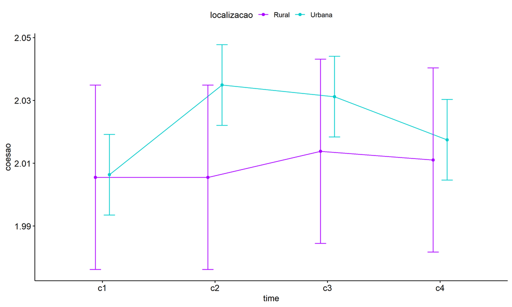

```r
pwc <- add_xy_position(pwc, x = "time", fun = "mean_se", dodge = 0.25)
pd <- position_dodge(width = 0.25)
ggline(emms, x = "time", y = "emmean", color = "localizacao",
       palette = c("#AA00FF","#00CCCC"),
       position = pd, ylab = "coesao") +
  geom_errorbar(aes(ymin = conf.low, ymax = conf.high, color = localizacao),
                position = pd, width = 0.2) +
  stat_pvalue_manual(pwc, hide.ns = T, tip.length = F, linetype = 1)
```

```r
(pwc <- ldat %>% group_by(localizacao) %>%
    emmeans_test(coesao ~ time, detailed = T, p.adjust.method = "bonferroni"))
```

```
## # A tibble: 12 × 15
##    localizacao term  .y.    group1 group2 null.value  estimate      se    df  conf.low conf.high
##  * <fct>       <chr> <chr>  <chr>  <chr>       <dbl>     <dbl>   <dbl> <dbl>     <dbl>     <dbl>
##  1 Rural       time  coesao c1     c2              0 -5.91e-15 0.0212   4496 -0.0415     0.0415
##  2 Rural       time  coesao c1     c3              0 -8.29e- 3 0.0212   4496 -0.0498     0.0332
##  3 Rural       time  coesao c1     c4              0 -5.52e- 3 0.0212   4496 -0.0470     0.0360
##  4 Rural       time  coesao c2     c3              0 -8.29e- 3 0.0212   4496 -0.0498     0.0332
##  5 Rural       time  coesao c2     c4              0 -5.52e- 3 0.0212   4496 -0.0470     0.0360
##  6 Rural       time  coesao c3     c4              0  2.76e- 3 0.0212   4496 -0.0387     0.0443
##  7 Urbana      time  coesao c1     c2              0 -2.86e- 2 0.00926  4496 -0.0467    -0.0104
##  8 Urbana      time  coesao c1     c3              0 -2.49e- 2 0.00926  4496 -0.0430    -0.00671
##  9 Urbana      time  coesao c1     c4              0 -1.11e- 2 0.00926  4496 -0.0293     0.00705
## 10 Urbana      time  coesao c2     c3              0  3.70e- 3 0.00926  4496 -0.0145     0.0219
## 11 Urbana      time  coesao c2     c4              0  1.75e- 2 0.00926  4496 -0.000700   0.0356
## 12 Urbana      time  coesao c3     c4              0  1.38e- 2 0.00926  4496 -0.00440    0.0319
## # ℹ 4 more variables: statistic <dbl>, p <dbl>, p.adj <dbl>, p.adj.signif <chr>
```

| localizacao | term | .y. | group1 | group2 | null.value | estimate | se | df | conf.low | conf.high | statistic | p | p.adj | p.adj.signif |
| --- | --- | --- | --- | --- | --- | --- | --- | --- | --- | --- | --- | --- | --- | --- |
| Rural | time | coesao | c1 | c2 | 0 | 0.000 | 0.021 | 4496 | -0.041 | 0.041 | 0.000 | 1.000 | 1.000 | ns |
| Rural | time | coesao | c1 | c3 | 0 | -0.008 | 0.021 | 4496 | -0.050 | 0.033 | -0.392 | 0.695 | 1.000 | ns |
| Rural | time | coesao | c1 | c4 | 0 | -0.006 | 0.021 | 4496 | -0.047 | 0.036 | -0.261 | 0.794 | 1.000 | ns |
| Rural | time | coesao | c2 | c3 | 0 | -0.008 | 0.021 | 4496 | -0.050 | 0.033 | -0.392 | 0.695 | 1.000 | ns |
| Rural | time | coesao | c2 | c4 | 0 | -0.006 | 0.021 | 4496 | -0.047 | 0.036 | -0.261 | 0.794 | 1.000 | ns |
| Rural | time | coesao | c3 | c4 | 0 | 0.003 | 0.021 | 4496 | -0.039 | 0.044 | 0.131 | 0.896 | 1.000 | ns |
| Urbana | time | coesao | c1 | c2 | 0 | -0.029 | 0.009 | 4496 | -0.047 | -0.010 | -3.084 | 0.002 | 0.012 | * |
| Urbana | time | coesao | c1 | c3 | 0 | -0.025 | 0.009 | 4496 | -0.043 | -0.007 | -2.685 | 0.007 | 0.044 | * |
| Urbana | time | coesao | c1 | c4 | 0 | -0.011 | 0.009 | 4496 | -0.029 | 0.007 | -1.199 | 0.230 | 1.000 | ns |
| Urbana | time | coesao | c2 | c3 | 0 | 0.004 | 0.009 | 4496 | -0.014 | 0.022 | 0.400 | 0.689 | 1.000 | ns |
| Urbana | time | coesao | c2 | c4 | 0 | 0.017 | 0.009 | 4496 | -0.001 | 0.036 | 1.885 | 0.060 | 0.357 | ns |
| Urbana | time | coesao | c3 | c4 | 0 | 0.014 | 0.009 | 4496 | -0.004 | 0.032 | 1.485 | 0.138 | 0.826 | ns |

```r
(emms <- get_emmeans(pwc))
```

```
## # A tibble: 8 × 8
##   localizacao time  emmean      se    df conf.low conf.high method
##   <fct>       <fct>  <dbl>   <dbl> <dbl>    <dbl>     <dbl> <chr>
## 1 Rural       c1      2.01 0.0150   4496     1.98      2.03 Emmeans test
## 2 Rural       c2      2.01 0.0150   4496     1.98      2.03 Emmeans test
## 3 Rural       c3      2.01 0.0150   4496     1.98      2.04 Emmeans test
## 4 Rural       c4      2.01 0.0150   4496     1.98      2.04 Emmeans test
## 5 Urbana      c1      2.01 0.00655  4496     1.99      2.02 Emmeans test
## 6 Urbana      c2      2.03 0.00655  4496     2.02      2.05 Emmeans test
## 7 Urbana      c3      2.03 0.00655  4496     2.02      2.04 Emmeans test
## 8 Urbana      c4      2.02 0.00655  4496     2.00      2.03 Emmeans test
```

| localizacao | time | emmean | se | df | conf.low | conf.high | method |
| --- | --- | --- | --- | --- | --- | --- | --- |
| Rural | c1 | 2.006 | 0.015 | 4496 | 1.976 | 2.035 | Emmeans test |
| Rural | c2 | 2.006 | 0.015 | 4496 | 1.976 | 2.035 | Emmeans test |
| Rural | c3 | 2.014 | 0.015 | 4496 | 1.984 | 2.043 | Emmeans test |
| Rural | c4 | 2.011 | 0.015 | 4496 | 1.982 | 2.040 | Emmeans test |
| Urbana | c1 | 2.006 | 0.007 | 4496 | 1.994 | 2.019 | Emmeans test |
| Urbana | c2 | 2.035 | 0.007 | 4496 | 2.022 | 2.048 | Emmeans test |
| Urbana | c3 | 2.031 | 0.007 | 4496 | 2.018 | 2.044 | Emmeans test |
| Urbana | c4 | 2.017 | 0.007 | 4496 | 2.005 | 2.030 | Emmeans test |

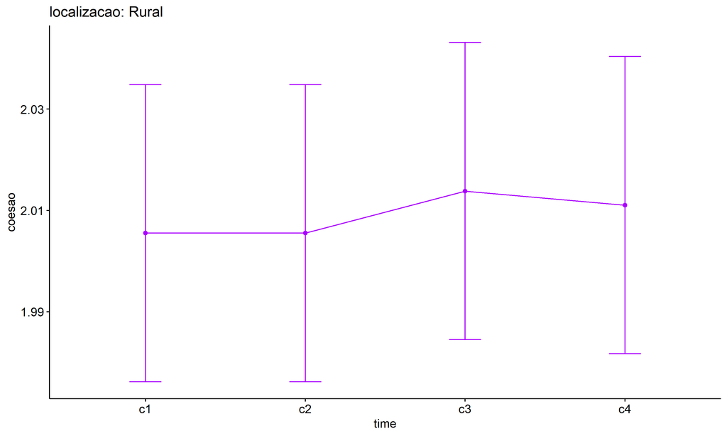

```r
emms.gg <- emms[which(emms$localizacao == "Rural"),]
if (nrow(emms.gg) > 0)
  ggline(emms.gg, x = "time", y = "emmean", color = "#AA00FF", ylab = "coesao") +
    geom_errorbar(aes(ymin = conf.low, ymax = conf.high),
                  width = 0.2, color = "#AA00FF") +
    stat_pvalue_manual(
      add_xy_position(pwc[which(pwc$localizacao == "Rural"),],
                      x = "time", fun = "mean_se"),
      hide.ns = T, color = "#AA00FF", tip.length = F) +
    labs(title = "localizacao: Rural")+
    theme(legend.text = element_blank())
```

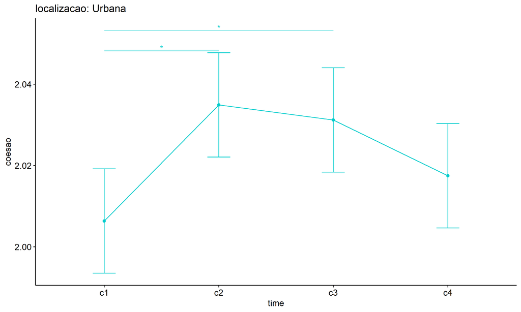

```r
emms.gg <- emms[which(emms$localizacao == "Urbana"),]
if (nrow(emms.gg) > 0)
  ggline(emms.gg, x = "time", y = "emmean", color = "#00CCCC", ylab = "coesao") +
    geom_errorbar(aes(ymin = conf.low, ymax = conf.high),
                  width = 0.2, color = "#00CCCC") +
    stat_pvalue_manual(
      add_xy_position(pwc[which(pwc$localizacao == "Urbana"),],
                      x = "time", fun = "mean_se"),
      hide.ns = T, color = "#00CCCC", tip.length = F) +
    labs(title = "localizacao: Urbana")+
    theme(legend.text = element_blank())
```

## PairWise Computation after removing non.normal data

```r
if (length(non.ids) > 0)
  (pwc2 <- ldat2 %>% group_by(time) %>%
     emmeans_test(coesao ~ localizacao, detailed = T, p.adjust.method = "bonferroni"))
```

```r
if (length(non.ids) > 0)
  (emms2 <- get_emmeans(pwc2))
```

```r
if (length(non.ids) > 0) {
  pwc2 <- add_xy_position(pwc2, x = "time", fun = "mean_se", dodge = 0.25)
  pd2 <- position_dodge(width = 0.25)

  ggline(emms2, x = "time", y = "emmean", color = "localizacao",
         palette = c("#AA00FF","#00CCCC"),
         position = pd, ylab = "coesao") +
    geom_errorbar(aes(ymin = conf.low, ymax = conf.high, color = localizacao),
                position = pd, width = 0.2) +
    stat_pvalue_manual(pwc2, hide.ns = T, tip.length = F, linetype = 1)
}
```

```r
if (length(non.ids) > 0)
  (pwc2 <- ldat2 %>% group_by(localizacao) %>%
     emmeans_test(coesao ~ time, detailed = T, p.adjust.method = "bonferroni"))
```

```r
if (length(non.ids) > 0)
  (emms2 <- get_emmeans(pwc2))
```

```r
if (length(non.ids) > 0) {
  emms.gg <- emms2[which(emms2$localizacao == "Rural"),]
  if (nrow(emms.gg) > 0)
    ggline(emms.gg, x = "time", y = "emmean", color = "#AA00FF", ylab = "coesao") +
    geom_errorbar(aes(ymin = conf.low, ymax = conf.high),
                  width = 0.2, color = "#AA00FF") +
    stat_pvalue_manual(
      add_xy_position(pwc[which(pwc$localizacao == "Rural"),],
                      x = "time", fun = "mean_se"),
      hide.ns = T, color = "#AA00FF", tip.length = F) +
    labs(title = "localizacao: Rural") +
    theme(legend.text = element_blank())
}
```

```r
if (length(non.ids) > 0) {
  emms.gg <- emms2[which(emms2$localizacao == "Urbana"),]
  if (nrow(emms.gg) > 0)
    ggline(emms.gg, x = "time", y = "emmean", color = "#00CCCC", ylab = "coesao") +
    geom_errorbar(aes(ymin = conf.low, ymax = conf.high),
                  width = 0.2, color = "#00CCCC") +
    stat_pvalue_manual(
      add_xy_position(pwc[which(pwc$localizacao == "Urbana"),],
                      x = "time", fun = "mean_se"),
      hide.ns = T, color = "#00CCCC", tip.length = F) +
    labs(title = "localizacao: Urbana") +
    theme(legend.text = element_blank())
}
```

# ANOVA: coesao ~ time*regiao + Error(id/time)

## Data Preparation

```r
data <- edat[,c("aluno_id","regiao","ciclo","coesao")]
data <- data[data$ciclo %in% c("Primeiro Ciclo","Segundo Ciclo","Terceiro Ciclo","Quarto Ciclo"),]
data$ciclo <- factor(data$ciclo, c("Primeiro Ciclo","Segundo Ciclo","Terceiro Ciclo","Quarto Ciclo"))
data <- unique(data)

wdat <- spread(data, ciclo, coesao)
wdat <- wdat[complete.cases(wdat),]
colnames(wdat) <- c("id","regiao","c1","c2","c3","c4")

ldat <- gather(wdat, key = time, value = coesao, c1,c2,c3,c4) %>%
  convert_as_factor(id, time)
ldat <- remove_group_data(ldat, "coesao", c("time", "regiao"), n.limit = 30)
ldat$regiao <- factor(ldat$regiao, sort(unique(ldat$regiao)))
```

### Check assumptions: Identifying Outliers

```r
outliers <- identify_outliers(group_by(ldat, time, regiao), coesao)
(outliers <- outliers[outliers$is.extreme == T,])
```

```
## # A tibble: 50 × 6
##    regiao   time  id                   coesao is.outlier is.extreme
##    <fct>    <fct> <fct>                 <dbl> <lgl>      <lgl>
##  1 Nordeste c1    IZ2Xmfi9jueckwdzfkiG      3 TRUE       TRUE
##  2 Nordeste c1    Kaj54imycuE0bbwH7xlD      3 TRUE       TRUE
##  3 Sudeste  c1    W8iXxSmW48zvfJyikMZb      4 TRUE       TRUE
##  4 Sudeste  c1    Y7HozU436KQ0wqdBGugu      4 TRUE       TRUE
##  5 Sul      c1    JRyGpNQA6mOEl1nzl1af      3 TRUE       TRUE
##  6 Nordeste c2    cuknOzzwN4oCRum5U5ph      5 TRUE       TRUE
##  7 Nordeste c2    EqNpFnKTbLOWH4nmuu6d      4 TRUE       TRUE
##  8 Nordeste c2    G7bqQeqXmsQ3kiJNeYlz      3 TRUE       TRUE
##  9 Nordeste c2    i5EZ8Ck9IgDueyMbw55v      3 TRUE       TRUE
## 10 Nordeste c2    oGUJyWRMYYbF9PNegJZh      4 TRUE       TRUE
## # ℹ 40 more rows
```

| regiao | time | id | coesao | is.outlier | is.extreme |
| --- | --- | --- | --- | --- | --- |
| Nordeste | c1 | IZ2Xmfi9jueckwdzfkiG | 3.0 | TRUE | TRUE |
| Nordeste | c1 | Kaj54imycuE0bbwH7xlD | 3.0 | TRUE | TRUE |
| Sudeste | c1 | W8iXxSmW48zvfJyikMZb | 4.0 | TRUE | TRUE |
| Sudeste | c1 | Y7HozU436KQ0wqdBGugu | 4.0 | TRUE | TRUE |
| Sul | c1 | JRyGpNQA6mOEl1nzl1af | 3.0 | TRUE | TRUE |
| Nordeste | c2 | cuknOzzwN4oCRum5U5ph | 5.0 | TRUE | TRUE |
| Nordeste | c2 | EqNpFnKTbLOWH4nmuu6d | 4.0 | TRUE | TRUE |
| Nordeste | c2 | G7bqQeqXmsQ3kiJNeYlz | 3.0 | TRUE | TRUE |
| Nordeste | c2 | i5EZ8Ck9IgDueyMbw55v | 3.0 | TRUE | TRUE |
| Nordeste | c2 | oGUJyWRMYYbF9PNegJZh | 4.0 | TRUE | TRUE |
| Nordeste | c2 | qyt5dpIrCcmnZfDJIazf | 4.0 | TRUE | TRUE |
| Nordeste | c2 | wgOGhRdGeAbGeHUAguQ5 | 5.0 | TRUE | TRUE |
| Nordeste | c2 | wQnhAn0Gfye5OP5zaTgh | 4.0 | TRUE | TRUE |
| Nordeste | c2 | xQIlV1qQiNpzi4Bna9Ut | 4.0 | TRUE | TRUE |
| Nordeste | c2 | XxtCdGkKAnQOx88fyxk4 | 3.0 | TRUE | TRUE |
| Sudeste | c2 | 0mGtUd2Axg2fjQmYZ4CC | 3.0 | TRUE | TRUE |
| Sudeste | c2 | G4NIt8gEc7nfeQ9k2OkL | 4.0 | TRUE | TRUE |
| Sudeste | c2 | HsQF2J0r79mHSWNe4l6n | 4.0 | TRUE | TRUE |
| Sudeste | c2 | j31LU8Xwm0EQ7Mihkhjj | 4.0 | TRUE | TRUE |
| Sudeste | c2 | W8iXxSmW48zvfJyikMZb | 4.0 | TRUE | TRUE |
| Sudeste | c2 | wuumviqqlrNK6QzeoJPr | 4.0 | TRUE | TRUE |
| Sudeste | c2 | xk7eC5haTYuFQaJovsBZ | 4.0 | TRUE | TRUE |
| Sudeste | c2 | YTYFFWzK4C7ejf1X1TUB | 4.0 | TRUE | TRUE |
| Nordeste | c3 | CCVIt7MPeYMUOCCyBxPh | 4.0 | TRUE | TRUE |
| Nordeste | c3 | E3u63riyMFS8A2cNBnvC | 3.0 | TRUE | TRUE |
| Nordeste | c3 | GN5vxU0haHKd9W22JGyk | 4.0 | TRUE | TRUE |
| Nordeste | c3 | i5EZ8Ck9IgDueyMbw55v | 5.0 | TRUE | TRUE |
| Nordeste | c3 | m5yRlxfIj73j4ossfTOB | 5.0 | TRUE | TRUE |
| Nordeste | c3 | PfTab7CnJIl6lys2Cxuq | 2.5 | TRUE | TRUE |
| Nordeste | c3 | vaOhaNww5ga5d9G6Cftj | 4.0 | TRUE | TRUE |
| Norte | c3 | QAyx2z41ILLaMN0o7pjc | 3.0 | TRUE | TRUE |
| Sudeste | c3 | 6bEKmKQpOuvY6PSQvzqj | 4.0 | TRUE | TRUE |
| Sudeste | c3 | EtUjsyq1GNevicwMDXlw | 3.5 | TRUE | TRUE |
| Sudeste | c3 | FkJFrnPezc8Ng4SSMx1z | 4.0 | TRUE | TRUE |
| Sudeste | c3 | HsQF2J0r79mHSWNe4l6n | 3.0 | TRUE | TRUE |
| Sudeste | c3 | j31LU8Xwm0EQ7Mihkhjj | 4.0 | TRUE | TRUE |
| Sudeste | c3 | TKvc4Eu2XaDXYPxuS7Qn | 4.0 | TRUE | TRUE |
| Sudeste | c3 | u65Z834z75LDIy0slvaX | 5.0 | TRUE | TRUE |
| Sudeste | c3 | xk7eC5haTYuFQaJovsBZ | 4.0 | TRUE | TRUE |
| Sul | c3 | OvwAQTWkdj8SYpPS8dgn | 4.0 | TRUE | TRUE |
| Nordeste | c4 | 3DdYC9Dpykr9Mtg6YR91 | 4.0 | TRUE | TRUE |
| Sudeste | c4 | 6bEKmKQpOuvY6PSQvzqj | 4.0 | TRUE | TRUE |
| Sudeste | c4 | DP1fbT1lGhLiBnOFILLi | 4.0 | TRUE | TRUE |
| Sudeste | c4 | fgNBRPWfCa0TP4bDO8d2 | 4.0 | TRUE | TRUE |
| Sudeste | c4 | IMHqraVHK59KiF08zsGi | 3.5 | TRUE | TRUE |
| Sudeste | c4 | jVbbowshsqkUpPuGSIMu | 4.0 | TRUE | TRUE |
| Sudeste | c4 | N7zTvCPK4nAUgH9eo3hg | 4.0 | TRUE | TRUE |
| Sudeste | c4 | zq67YfRtJ2g4hWPYAfkU | 3.0 | TRUE | TRUE |
| Sul | c4 | tVMilOzYDlVoWwNezYUi | 4.0 | TRUE | TRUE |
| Sul | c4 | VRWfIoYUFgdA8nGO5bpD | 4.0 | TRUE | TRUE |

### Check assumptions: Normality Test

```r
(normality.df <- normality.test.per.groups(ldat, "coesao", c("time", "regiao")))
```

```
##       var variable time       regiao   n  skewness  kurtosis symmetry statistic     method p
## 1  coesao   coesao   c1 Centro-Oeste  48  0.000000   0.00000 few data        NA       <NA> 1
## 2  coesao   coesao   c1     Nordeste 545  0.000000   0.00000 few data        NA       <NA> 1
## 3  coesao   coesao   c1        Norte  78  0.000000   0.00000 few data        NA       <NA> 1
## 4  coesao   coesao   c1      Sudeste 393  0.000000   0.00000 few data        NA       <NA> 1
## 5  coesao   coesao   c1          Sul  62  0.000000   0.00000 few data        NA       <NA> 1
## 6  coesao   coesao   c2 Centro-Oeste  48  0.000000   0.00000 few data        NA       <NA> 1
## 7  coesao   coesao   c2     Nordeste 545  8.429240  74.34603       NO  814.9720 D'Agostino 0
## 8  coesao   coesao   c2        Norte  78  0.000000   0.00000 few data        NA       <NA> 1
## 9  coesao   coesao   c2      Sudeste 393  0.000000   0.00000 few data        NA       <NA> 1
## 10 coesao   coesao   c2          Sul  62  0.000000   0.00000 few data        NA       <NA> 1
## 11 coesao   coesao   c3 Centro-Oeste  48  0.000000   0.00000 few data        NA       <NA> 1
## 12 coesao   coesao   c3     Nordeste 545 10.404132 112.52142       NO  920.5753 D'Agostino 0
## 13 coesao   coesao   c3        Norte  78  0.000000   0.00000 few data        NA       <NA> 1
## 14 coesao   coesao   c3      Sudeste 393  7.502452  57.97435       NO  561.6308 D'Agostino 0
```

[output cut: 27 more lines]

| var | variable | time | regiao | n | skewness | kurtosis | symmetry | statistic | method | p | p.signif | normality |
| --- | --- | --- | --- | --- | --- | --- | --- | --- | --- | --- | --- | --- |
| coesao | coesao | c1 | Centro-Oeste | 48 | 0.000 | 0.000 | few data | NA | NA | 1 | NA | NO |
| coesao | coesao | c1 | Nordeste | 545 | 0.000 | 0.000 | few data | NA | NA | 1 | NA | NO |
| coesao | coesao | c1 | Norte | 78 | 0.000 | 0.000 | few data | NA | NA | 1 | NA | NO |
| coesao | coesao | c1 | Sudeste | 393 | 0.000 | 0.000 | few data | NA | NA | 1 | NA | NO |
| coesao | coesao | c1 | Sul | 62 | 0.000 | 0.000 | few data | NA | NA | 1 | NA | NO |
| coesao | coesao | c2 | Centro-Oeste | 48 | 0.000 | 0.000 | few data | NA | NA | 1 | NA | NO |
| coesao | coesao | c2 | Nordeste | 545 | 8.429 | 74.346 | NO | 814.972 | D’Agostino | 0 | **** | - |
| coesao | coesao | c2 | Norte | 78 | 0.000 | 0.000 | few data | NA | NA | 1 | NA | NO |
| coesao | coesao | c2 | Sudeste | 393 | 0.000 | 0.000 | few data | NA | NA | 1 | NA | NO |
| coesao | coesao | c2 | Sul | 62 | 0.000 | 0.000 | few data | NA | NA | 1 | NA | NO |
| coesao | coesao | c3 | Centro-Oeste | 48 | 0.000 | 0.000 | few data | NA | NA | 1 | NA | NO |
| coesao | coesao | c3 | Nordeste | 545 | 10.404 | 112.521 | NO | 920.575 | D’Agostino | 0 | **** | - |
| coesao | coesao | c3 | Norte | 78 | 0.000 | 0.000 | few data | NA | NA | 1 | NA | NO |
| coesao | coesao | c3 | Sudeste | 393 | 7.502 | 57.974 | NO | 561.631 | D’Agostino | 0 | **** | - |
| coesao | coesao | c3 | Sul | 62 | 0.000 | 0.000 | few data | NA | NA | 1 | NA | NO |
| coesao | coesao | c4 | Centro-Oeste | 48 | 0.000 | 0.000 | few data | NA | NA | 1 | NA | NO |
| coesao | coesao | c4 | Nordeste | 545 | 0.000 | 0.000 | few data | NA | NA | 1 | NA | NO |
| coesao | coesao | c4 | Norte | 78 | 0.000 | 0.000 | few data | NA | NA | 1 | NA | NO |
| coesao | coesao | c4 | Sudeste | 393 | 7.625 | 57.314 | NO | 565.637 | D’Agostino | 0 | **** | - |
| coesao | coesao | c4 | Sul | 62 | 0.000 | 0.000 | few data | NA | NA | 1 | NA | NO |

```r
(non.ids <- unique(do.call(
  c, lapply(which(normality.df$normality == 'NO'), FUN = function(i) {
  idx = which(ldat$time == normality.df$time[i] &
                ldat$regiao == normality.df$regiao[i])
  getNonNormal(ldat$"coesao"[idx], ldat$id[idx])
}))))
```

```r
if (length(non.ids) > 0)
  ldat2 <- ldat[!ldat$id %in% non.ids,]
```

### Summary Statistics

```r
(sdat <- ldat %>% group_by(time, regiao) %>%
   get_summary_stats(coesao, type = "mean_sd"))
```

```
## # A tibble: 20 × 6
##    regiao       time  variable     n  mean    sd
##    <fct>        <fct> <fct>    <dbl> <dbl> <dbl>
##  1 Centro-Oeste c1    coesao      48  2    0
##  2 Nordeste     c1    coesao     545  2.00 0.061
##  3 Norte        c1    coesao      78  2    0
##  4 Sudeste      c1    coesao     393  2.01 0.142
##  5 Sul          c1    coesao      62  2.02 0.127
##  6 Centro-Oeste c2    coesao      48  2    0
##  7 Nordeste     c2    coesao     545  2.04 0.272
##  8 Norte        c2    coesao      78  2    0
##  9 Sudeste      c2    coesao     393  2.04 0.269
## 10 Sul          c2    coesao      62  2    0
## 11 Centro-Oeste c3    coesao      48  2    0
## 12 Nordeste     c3    coesao     545  2.02 0.238
## 13 Norte        c3    coesao      78  2.01 0.113
## 14 Sudeste      c3    coesao     393  2.04 0.284
## 15 Sul          c3    coesao      62  2.03 0.254
## 16 Centro-Oeste c4    coesao      48  2    0
## 17 Nordeste     c4    coesao     545  2.00 0.086
## 18 Norte        c4    coesao      78  2    0
## 19 Sudeste      c4    coesao     393  2.03 0.241
## 20 Sul          c4    coesao      62  2.06 0.356
```

| regiao | time | variable | n | mean | sd |
| --- | --- | --- | --- | --- | --- |
| Centro-Oeste | c1 | coesao | 48 | 2.000 | 0.000 |
| Nordeste | c1 | coesao | 545 | 2.004 | 0.061 |
| Norte | c1 | coesao | 78 | 2.000 | 0.000 |
| Sudeste | c1 | coesao | 393 | 2.010 | 0.142 |
| Sul | c1 | coesao | 62 | 2.016 | 0.127 |
| Centro-Oeste | c2 | coesao | 48 | 2.000 | 0.000 |
| Nordeste | c2 | coesao | 545 | 2.035 | 0.272 |
| Norte | c2 | coesao | 78 | 2.000 | 0.000 |
| Sudeste | c2 | coesao | 393 | 2.038 | 0.269 |
| Sul | c2 | coesao | 62 | 2.000 | 0.000 |
| Centro-Oeste | c3 | coesao | 48 | 2.000 | 0.000 |
| Nordeste | c3 | coesao | 545 | 2.025 | 0.238 |
| Norte | c3 | coesao | 78 | 2.013 | 0.113 |
| Sudeste | c3 | coesao | 393 | 2.039 | 0.284 |
| Sul | c3 | coesao | 62 | 2.032 | 0.254 |
| Centro-Oeste | c4 | coesao | 48 | 2.000 | 0.000 |
| Nordeste | c4 | coesao | 545 | 2.004 | 0.086 |
| Norte | c4 | coesao | 78 | 2.000 | 0.000 |
| Sudeste | c4 | coesao | 393 | 2.032 | 0.241 |
| Sul | c4 | coesao | 62 | 2.065 | 0.356 |

```r
if (length(non.ids) > 0)
  (sdat <- ldat2 %>% group_by(time, regiao) %>%
      get_summary_stats(coesao, type = "mean_sd"))
```

| regiao | time | variable | n | mean | sd |
| --- | --- | --- | --- | --- | --- |
| Centro-Oeste | c1 | coesao | 48 | 2.000 | 0.000 |
| Nordeste | c1 | coesao | 545 | 2.004 | 0.061 |
| Norte | c1 | coesao | 78 | 2.000 | 0.000 |
| Sudeste | c1 | coesao | 393 | 2.010 | 0.142 |
| Sul | c1 | coesao | 62 | 2.016 | 0.127 |
| Centro-Oeste | c2 | coesao | 48 | 2.000 | 0.000 |
| Nordeste | c2 | coesao | 545 | 2.035 | 0.272 |
| Norte | c2 | coesao | 78 | 2.000 | 0.000 |
| Sudeste | c2 | coesao | 393 | 2.038 | 0.269 |
| Sul | c2 | coesao | 62 | 2.000 | 0.000 |
| Centro-Oeste | c3 | coesao | 48 | 2.000 | 0.000 |
| Nordeste | c3 | coesao | 545 | 2.025 | 0.238 |
| Norte | c3 | coesao | 78 | 2.013 | 0.113 |
| Sudeste | c3 | coesao | 393 | 2.039 | 0.284 |
| Sul | c3 | coesao | 62 | 2.032 | 0.254 |
| Centro-Oeste | c4 | coesao | 48 | 2.000 | 0.000 |
| Nordeste | c4 | coesao | 545 | 2.004 | 0.086 |
| Norte | c4 | coesao | 78 | 2.000 | 0.000 |
| Sudeste | c4 | coesao | 393 | 2.032 | 0.241 |
| Sul | c4 | coesao | 62 | 2.065 | 0.356 |

## ANOVA Computation

```r
(res.aov <- anova_test(ldat, dv = coesao, wid = id, between = regiao, within = time))
```

```
## ANOVA Table (type III tests)
##
## $ANOVA
##        Effect DFn  DFd     F     p p<.05      ges
## 1      regiao   4 1121 1.843 0.118       0.002000
## 2        time   3 3363 0.617 0.604       0.000385
## 3 regiao:time  12 3363 0.756 0.697       0.002000
##
## $`Mauchly's Test for Sphericity`
##        Effect     W                                                                        p p<.05
## 1        time 0.749 0.0000000000000000000000000000000000000000000000000000000000000000000719     *
## 2 regiao:time 0.749 0.0000000000000000000000000000000000000000000000000000000000000000000719     *
##
## $`Sphericity Corrections`
##        Effect   GGe         DF[GG] p[GG] p[GG]<.05   HFe        DF[HF] p[HF] p[HF]<.05
## 1        time 0.874  2.62, 2937.99 0.582           0.876  2.63, 2945.5 0.583
## 2 regiao:time 0.874 10.48, 2937.99 0.678           0.876 10.51, 2945.5 0.679
```

| Effect | DFn | DFd | F | p | p<.05 | ges |
| --- | --- | --- | --- | --- | --- | --- |
| regiao | 4 | 1121 | 1.843 | 0.118 |  | 0.002 |
| time | 3 | 3363 | 0.617 | 0.604 |  | 0.000 |
| regiao:time | 12 | 3363 | 0.756 | 0.697 |  | 0.002 |

| Effect | W | p | p<.05 |
| --- | --- | --- | --- |
| time | 0.749 | 0 | * |
| regiao:time | 0.749 | 0 | * |

| Effect | GGe | DF[GG] | p[GG] | p[GG]<.05 | HFe | DF[HF] | p[HF] | p[HF]<.05 |
| --- | --- | --- | --- | --- | --- | --- | --- | --- |
| time | 0.874 | 2.62, 2937.99 | 0.582 |  | 0.876 | 2.63, 2945.5 | 0.583 |  |
| regiao:time | 0.874 | 10.48, 2937.99 | 0.678 |  | 0.876 | 10.51, 2945.5 | 0.679 |  |

## ANOVA Computation after removing non.normal data

```r
if (length(non.ids) > 0)
  (res.aov2 <- anova_test(ldat2, dv = coesao, wid = id, between = regiao , within = time))
```

## PairWise Computation

```r
(pwc <- ldat %>% group_by(time) %>%
   emmeans_test(coesao ~ regiao, detailed = T, p.adjust.method = "bonferroni"))
```

[output not shown]

```r
(emms <- get_emmeans(pwc))
```

```
## # A tibble: 20 × 8
##    time  regiao       emmean      se    df conf.low conf.high method
##    <fct> <fct>         <dbl>   <dbl> <dbl>    <dbl>     <dbl> <chr>
##  1 c1    Centro-Oeste   2.00 0.0291   4484     1.94      2.06 Emmeans test
##  2 c1    Nordeste       2.00 0.00862  4484     1.99      2.02 Emmeans test
##  3 c1    Norte          2.00 0.0228   4484     1.96      2.04 Emmeans test
##  4 c1    Sudeste        2.01 0.0102   4484     1.99      2.03 Emmeans test
##  5 c1    Sul            2.02 0.0256   4484     1.97      2.07 Emmeans test
##  6 c2    Centro-Oeste   2.00 0.0291   4484     1.94      2.06 Emmeans test
##  7 c2    Nordeste       2.03 0.00862  4484     2.02      2.05 Emmeans test
##  8 c2    Norte          2.00 0.0228   4484     1.96      2.04 Emmeans test
##  9 c2    Sudeste        2.04 0.0102   4484     2.02      2.06 Emmeans test
## 10 c2    Sul            2.00 0.0256   4484     1.95      2.05 Emmeans test
## 11 c3    Centro-Oeste   2.00 0.0291   4484     1.94      2.06 Emmeans test
## 12 c3    Nordeste       2.02 0.00862  4484     2.01      2.04 Emmeans test
## 13 c3    Norte          2.01 0.0228   4484     1.97      2.06 Emmeans test
## 14 c3    Sudeste        2.04 0.0102   4484     2.02      2.06 Emmeans test
## 15 c3    Sul            2.03 0.0256   4484     1.98      2.08 Emmeans test
## 16 c4    Centro-Oeste   2.00 0.0291   4484     1.94      2.06 Emmeans test
## 17 c4    Nordeste       2.00 0.00862  4484     1.99      2.02 Emmeans test
## 18 c4    Norte          2.00 0.0228   4484     1.96      2.04 Emmeans test
## 19 c4    Sudeste        2.03 0.0102   4484     2.01      2.05 Emmeans test
## 20 c4    Sul            2.06 0.0256   4484     2.01      2.11 Emmeans test
```

| time | regiao | emmean | se | df | conf.low | conf.high | method |
| --- | --- | --- | --- | --- | --- | --- | --- |
| c1 | Centro-Oeste | 2.000 | 0.029 | 4484 | 1.943 | 2.057 | Emmeans test |
| c1 | Nordeste | 2.004 | 0.009 | 4484 | 1.987 | 2.021 | Emmeans test |
| c1 | Norte | 2.000 | 0.023 | 4484 | 1.955 | 2.045 | Emmeans test |
| c1 | Sudeste | 2.010 | 0.010 | 4484 | 1.990 | 2.030 | Emmeans test |
| c1 | Sul | 2.016 | 0.026 | 4484 | 1.966 | 2.066 | Emmeans test |
| c2 | Centro-Oeste | 2.000 | 0.029 | 4484 | 1.943 | 2.057 | Emmeans test |
| c2 | Nordeste | 2.035 | 0.009 | 4484 | 2.018 | 2.052 | Emmeans test |
| c2 | Norte | 2.000 | 0.023 | 4484 | 1.955 | 2.045 | Emmeans test |
| c2 | Sudeste | 2.038 | 0.010 | 4484 | 2.018 | 2.058 | Emmeans test |
| c2 | Sul | 2.000 | 0.026 | 4484 | 1.950 | 2.050 | Emmeans test |
| c3 | Centro-Oeste | 2.000 | 0.029 | 4484 | 1.943 | 2.057 | Emmeans test |
| c3 | Nordeste | 2.025 | 0.009 | 4484 | 2.008 | 2.042 | Emmeans test |
| c3 | Norte | 2.013 | 0.023 | 4484 | 1.968 | 2.058 | Emmeans test |
| c3 | Sudeste | 2.039 | 0.010 | 4484 | 2.020 | 2.059 | Emmeans test |
| c3 | Sul | 2.032 | 0.026 | 4484 | 1.982 | 2.082 | Emmeans test |
| c4 | Centro-Oeste | 2.000 | 0.029 | 4484 | 1.943 | 2.057 | Emmeans test |
| c4 | Nordeste | 2.004 | 0.009 | 4484 | 1.987 | 2.021 | Emmeans test |
| c4 | Norte | 2.000 | 0.023 | 4484 | 1.955 | 2.045 | Emmeans test |
| c4 | Sudeste | 2.032 | 0.010 | 4484 | 2.012 | 2.052 | Emmeans test |
| c4 | Sul | 2.065 | 0.026 | 4484 | 2.014 | 2.115 | Emmeans test |

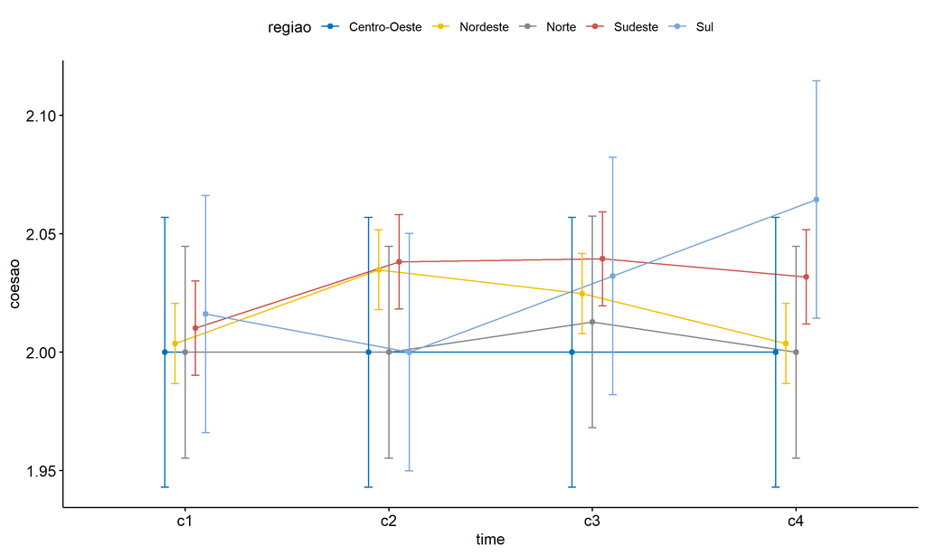

```r
pwc <- add_xy_position(pwc, x = "time", fun = "mean_se", dodge = 0.25)
pd <- position_dodge(width = 0.25)
ggline(emms, x = "time", y = "emmean", color = "regiao",
       palette = c("#0073C2FF","#EFC000FF","#868686FF","#CD534CFF","#7AA6DCFF"),
       position = pd, ylab = "coesao") +
  geom_errorbar(aes(ymin = conf.low, ymax = conf.high, color = regiao),
                position = pd, width = 0.2) +
  stat_pvalue_manual(pwc, hide.ns = T, tip.length = F, linetype = 1)
```

```r
(pwc <- ldat %>% group_by(regiao) %>%
    emmeans_test(coesao ~ time, detailed = T, p.adjust.method = "bonferroni"))
```

```
## # A tibble: 30 × 15
##    regiao    term  .y.   group1 group2 null.value  estimate     se    df conf.low conf.high statistic
##  * <fct>     <chr> <chr> <chr>  <chr>       <dbl>     <dbl>  <dbl> <dbl>    <dbl>     <dbl>     <dbl>
##  1 Centro-O… time  coes… c1     c2              0 -1.26e-16 0.0411  4484  -0.0806   0.0806  -3.06e-15
##  2 Centro-O… time  coes… c1     c3              0  1.69e-15 0.0411  4484  -0.0806   0.0806   4.12e-14
##  3 Centro-O… time  coes… c1     c4              0 -1.20e-15 0.0411  4484  -0.0806   0.0806  -2.92e-14
##  4 Centro-O… time  coes… c2     c3              0  1.82e-15 0.0411  4484  -0.0806   0.0806   4.43e-14
##  5 Centro-O… time  coes… c2     c4              0 -1.08e-15 0.0411  4484  -0.0806   0.0806  -2.62e-14
##  6 Centro-O… time  coes… c3     c4              0 -2.90e-15 0.0411  4484  -0.0806   0.0806  -7.05e-14
##  7 Nordeste  time  coes… c1     c2              0 -3.12e- 2 0.0122  4484  -0.0551  -0.00728 -2.56e+ 0
##  8 Nordeste  time  coes… c1     c3              0 -2.11e- 2 0.0122  4484  -0.0450   0.00281 -1.73e+ 0
##  9 Nordeste  time  coes… c1     c4              0  6.99e-15 0.0122  4484  -0.0239   0.0239   5.73e-13
## 10 Nordeste  time  coes… c2     c3              0  1.01e- 2 0.0122  4484  -0.0138   0.0340   8.27e- 1
## # ℹ 20 more rows
## # ℹ 3 more variables: p <dbl>, p.adj <dbl>, p.adj.signif <chr>
```

| regiao | term | .y. | group1 | group2 | null.value | estimate | se | df | conf.low | conf.high | statistic | p | p.adj | p.adj.signif |
| --- | --- | --- | --- | --- | --- | --- | --- | --- | --- | --- | --- | --- | --- | --- |
| Centro-Oeste | time | coesao | c1 | c2 | 0 | 0.000 | 0.041 | 4484 | -0.081 | 0.081 | 0.000 | 1.000 | 1.000 | ns |
| Centro-Oeste | time | coesao | c1 | c3 | 0 | 0.000 | 0.041 | 4484 | -0.081 | 0.081 | 0.000 | 1.000 | 1.000 | ns |
| Centro-Oeste | time | coesao | c1 | c4 | 0 | 0.000 | 0.041 | 4484 | -0.081 | 0.081 | 0.000 | 1.000 | 1.000 | ns |
| Centro-Oeste | time | coesao | c2 | c3 | 0 | 0.000 | 0.041 | 4484 | -0.081 | 0.081 | 0.000 | 1.000 | 1.000 | ns |
| Centro-Oeste | time | coesao | c2 | c4 | 0 | 0.000 | 0.041 | 4484 | -0.081 | 0.081 | 0.000 | 1.000 | 1.000 | ns |
| Centro-Oeste | time | coesao | c3 | c4 | 0 | 0.000 | 0.041 | 4484 | -0.081 | 0.081 | 0.000 | 1.000 | 1.000 | ns |
| Nordeste | time | coesao | c1 | c2 | 0 | -0.031 | 0.012 | 4484 | -0.055 | -0.007 | -2.557 | 0.011 | 0.063 | ns |
| Nordeste | time | coesao | c1 | c3 | 0 | -0.021 | 0.012 | 4484 | -0.045 | 0.003 | -1.730 | 0.084 | 0.502 | ns |
| Nordeste | time | coesao | c1 | c4 | 0 | 0.000 | 0.012 | 4484 | -0.024 | 0.024 | 0.000 | 1.000 | 1.000 | ns |
| Nordeste | time | coesao | c2 | c3 | 0 | 0.010 | 0.012 | 4484 | -0.014 | 0.034 | 0.827 | 0.408 | 1.000 | ns |
| Nordeste | time | coesao | c2 | c4 | 0 | 0.031 | 0.012 | 4484 | 0.007 | 0.055 | 2.557 | 0.011 | 0.063 | ns |
| Nordeste | time | coesao | c3 | c4 | 0 | 0.021 | 0.012 | 4484 | -0.003 | 0.045 | 1.730 | 0.084 | 0.502 | ns |
| Norte | time | coesao | c1 | c2 | 0 | 0.000 | 0.032 | 4484 | -0.063 | 0.063 | 0.000 | 1.000 | 1.000 | ns |
| Norte | time | coesao | c1 | c3 | 0 | -0.013 | 0.032 | 4484 | -0.076 | 0.050 | -0.398 | 0.691 | 1.000 | ns |
| Norte | time | coesao | c1 | c4 | 0 | 0.000 | 0.032 | 4484 | -0.063 | 0.063 | 0.000 | 1.000 | 1.000 | ns |
| Norte | time | coesao | c2 | c3 | 0 | -0.013 | 0.032 | 4484 | -0.076 | 0.050 | -0.398 | 0.691 | 1.000 | ns |
| Norte | time | coesao | c2 | c4 | 0 | 0.000 | 0.032 | 4484 | -0.063 | 0.063 | 0.000 | 1.000 | 1.000 | ns |
| Norte | time | coesao | c3 | c4 | 0 | 0.013 | 0.032 | 4484 | -0.050 | 0.076 | 0.398 | 0.691 | 1.000 | ns |
| Sudeste | time | coesao | c1 | c2 | 0 | -0.028 | 0.014 | 4484 | -0.056 | 0.000 | -1.949 | 0.051 | 0.308 | ns |
| Sudeste | time | coesao | c1 | c3 | 0 | -0.029 | 0.014 | 4484 | -0.057 | -0.001 | -2.037 | 0.042 | 0.250 | ns |
| Sudeste | time | coesao | c1 | c4 | 0 | -0.022 | 0.014 | 4484 | -0.050 | 0.007 | -1.506 | 0.132 | 0.793 | ns |
| Sudeste | time | coesao | c2 | c3 | 0 | -0.001 | 0.014 | 4484 | -0.029 | 0.027 | -0.089 | 0.929 | 1.000 | ns |
| Sudeste | time | coesao | c2 | c4 | 0 | 0.006 | 0.014 | 4484 | -0.022 | 0.035 | 0.443 | 0.658 | 1.000 | ns |
| Sudeste | time | coesao | c3 | c4 | 0 | 0.008 | 0.014 | 4484 | -0.021 | 0.036 | 0.531 | 0.595 | 1.000 | ns |
| Sul | time | coesao | c1 | c2 | 0 | 0.016 | 0.036 | 4484 | -0.055 | 0.087 | 0.446 | 0.656 | 1.000 | ns |
| Sul | time | coesao | c1 | c3 | 0 | -0.016 | 0.036 | 4484 | -0.087 | 0.055 | -0.446 | 0.656 | 1.000 | ns |
| Sul | time | coesao | c1 | c4 | 0 | -0.048 | 0.036 | 4484 | -0.119 | 0.023 | -1.338 | 0.181 | 1.000 | ns |
| Sul | time | coesao | c2 | c3 | 0 | -0.032 | 0.036 | 4484 | -0.103 | 0.039 | -0.892 | 0.372 | 1.000 | ns |
| Sul | time | coesao | c2 | c4 | 0 | -0.065 | 0.036 | 4484 | -0.135 | 0.006 | -1.784 | 0.074 | 0.447 | ns |
| Sul | time | coesao | c3 | c4 | 0 | -0.032 | 0.036 | 4484 | -0.103 | 0.039 | -0.892 | 0.372 | 1.000 | ns |

```r
(emms <- get_emmeans(pwc))
```

```
## # A tibble: 20 × 8
##    regiao       time  emmean      se    df conf.low conf.high method
##    <fct>        <fct>  <dbl>   <dbl> <dbl>    <dbl>     <dbl> <chr>
##  1 Centro-Oeste c1      2.00 0.0291   4484     1.94      2.06 Emmeans test
##  2 Centro-Oeste c2      2.00 0.0291   4484     1.94      2.06 Emmeans test
##  3 Centro-Oeste c3      2.00 0.0291   4484     1.94      2.06 Emmeans test
##  4 Centro-Oeste c4      2.00 0.0291   4484     1.94      2.06 Emmeans test
##  5 Nordeste     c1      2.00 0.00862  4484     1.99      2.02 Emmeans test
##  6 Nordeste     c2      2.03 0.00862  4484     2.02      2.05 Emmeans test
##  7 Nordeste     c3      2.02 0.00862  4484     2.01      2.04 Emmeans test
##  8 Nordeste     c4      2.00 0.00862  4484     1.99      2.02 Emmeans test
##  9 Norte        c1      2.00 0.0228   4484     1.96      2.04 Emmeans test
## 10 Norte        c2      2.00 0.0228   4484     1.96      2.04 Emmeans test
## 11 Norte        c3      2.01 0.0228   4484     1.97      2.06 Emmeans test
## 12 Norte        c4      2.00 0.0228   4484     1.96      2.04 Emmeans test
## 13 Sudeste      c1      2.01 0.0102   4484     1.99      2.03 Emmeans test
## 14 Sudeste      c2      2.04 0.0102   4484     2.02      2.06 Emmeans test
## 15 Sudeste      c3      2.04 0.0102   4484     2.02      2.06 Emmeans test
## 16 Sudeste      c4      2.03 0.0102   4484     2.01      2.05 Emmeans test
## 17 Sul          c1      2.02 0.0256   4484     1.97      2.07 Emmeans test
## 18 Sul          c2      2.00 0.0256   4484     1.95      2.05 Emmeans test
## 19 Sul          c3      2.03 0.0256   4484     1.98      2.08 Emmeans test
## 20 Sul          c4      2.06 0.0256   4484     2.01      2.11 Emmeans test
```

| regiao | time | emmean | se | df | conf.low | conf.high | method |
| --- | --- | --- | --- | --- | --- | --- | --- |
| Centro-Oeste | c1 | 2.000 | 0.029 | 4484 | 1.943 | 2.057 | Emmeans test |
| Centro-Oeste | c2 | 2.000 | 0.029 | 4484 | 1.943 | 2.057 | Emmeans test |
| Centro-Oeste | c3 | 2.000 | 0.029 | 4484 | 1.943 | 2.057 | Emmeans test |
| Centro-Oeste | c4 | 2.000 | 0.029 | 4484 | 1.943 | 2.057 | Emmeans test |
| Nordeste | c1 | 2.004 | 0.009 | 4484 | 1.987 | 2.021 | Emmeans test |
| Nordeste | c2 | 2.035 | 0.009 | 4484 | 2.018 | 2.052 | Emmeans test |
| Nordeste | c3 | 2.025 | 0.009 | 4484 | 2.008 | 2.042 | Emmeans test |
| Nordeste | c4 | 2.004 | 0.009 | 4484 | 1.987 | 2.021 | Emmeans test |
| Norte | c1 | 2.000 | 0.023 | 4484 | 1.955 | 2.045 | Emmeans test |
| Norte | c2 | 2.000 | 0.023 | 4484 | 1.955 | 2.045 | Emmeans test |
| Norte | c3 | 2.013 | 0.023 | 4484 | 1.968 | 2.058 | Emmeans test |
| Norte | c4 | 2.000 | 0.023 | 4484 | 1.955 | 2.045 | Emmeans test |
| Sudeste | c1 | 2.010 | 0.010 | 4484 | 1.990 | 2.030 | Emmeans test |
| Sudeste | c2 | 2.038 | 0.010 | 4484 | 2.018 | 2.058 | Emmeans test |
| Sudeste | c3 | 2.039 | 0.010 | 4484 | 2.020 | 2.059 | Emmeans test |
| Sudeste | c4 | 2.032 | 0.010 | 4484 | 2.012 | 2.052 | Emmeans test |
| Sul | c1 | 2.016 | 0.026 | 4484 | 1.966 | 2.066 | Emmeans test |
| Sul | c2 | 2.000 | 0.026 | 4484 | 1.950 | 2.050 | Emmeans test |
| Sul | c3 | 2.032 | 0.026 | 4484 | 1.982 | 2.082 | Emmeans test |
| Sul | c4 | 2.065 | 0.026 | 4484 | 2.014 | 2.115 | Emmeans test |

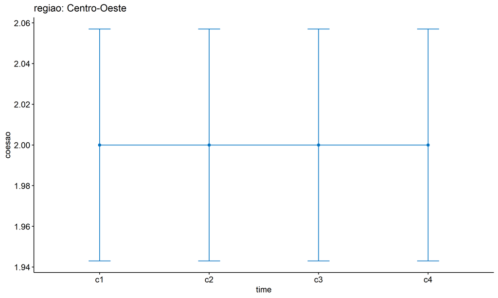

```r
emms.gg <- emms[which(emms$regiao == "Centro-Oeste"),]
if (nrow(emms.gg) > 0)
  ggline(emms.gg, x = "time", y = "emmean", color = "#0073C2FF", ylab = "coesao") +
    geom_errorbar(aes(ymin = conf.low, ymax = conf.high),
                  width = 0.2, color = "#0073C2FF") +
    stat_pvalue_manual(
      add_xy_position(pwc[which(pwc$regiao == "Centro-Oeste"),],
                      x = "time", fun = "mean_se"),
      hide.ns = T, color = "#0073C2FF", tip.length = F) +
    labs(title = "regiao: Centro-Oeste")+
    theme(legend.text = element_blank())
```

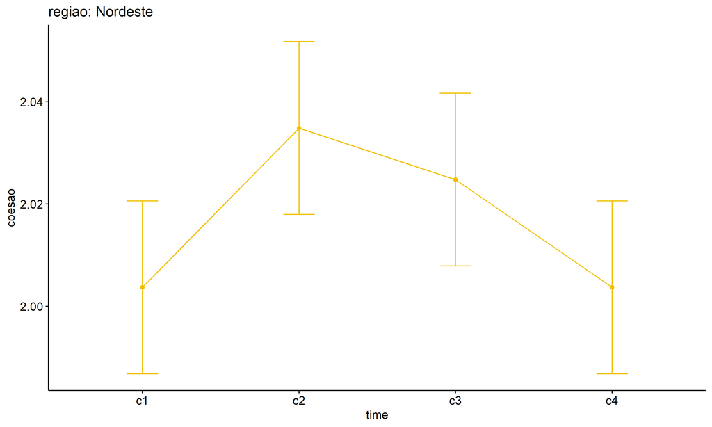

```r
emms.gg <- emms[which(emms$regiao == "Nordeste"),]
if (nrow(emms.gg) > 0)
  ggline(emms.gg, x = "time", y = "emmean", color = "#EFC000FF", ylab = "coesao") +
    geom_errorbar(aes(ymin = conf.low, ymax = conf.high),
                  width = 0.2, color = "#EFC000FF") +
    stat_pvalue_manual(
      add_xy_position(pwc[which(pwc$regiao == "Nordeste"),],
                      x = "time", fun = "mean_se"),
      hide.ns = T, color = "#EFC000FF", tip.length = F) +
    labs(title = "regiao: Nordeste")+
    theme(legend.text = element_blank())
```

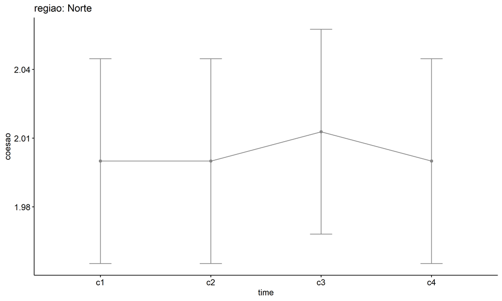

```r
emms.gg <- emms[which(emms$regiao == "Norte"),]
if (nrow(emms.gg) > 0)
  ggline(emms.gg, x = "time", y = "emmean", color = "#868686FF", ylab = "coesao") +
    geom_errorbar(aes(ymin = conf.low, ymax = conf.high),
                  width = 0.2, color = "#868686FF") +
    stat_pvalue_manual(
      add_xy_position(pwc[which(pwc$regiao == "Norte"),],
                      x = "time", fun = "mean_se"),
      hide.ns = T, color = "#868686FF", tip.length = F) +
    labs(title = "regiao: Norte")+
    theme(legend.text = element_blank())
```

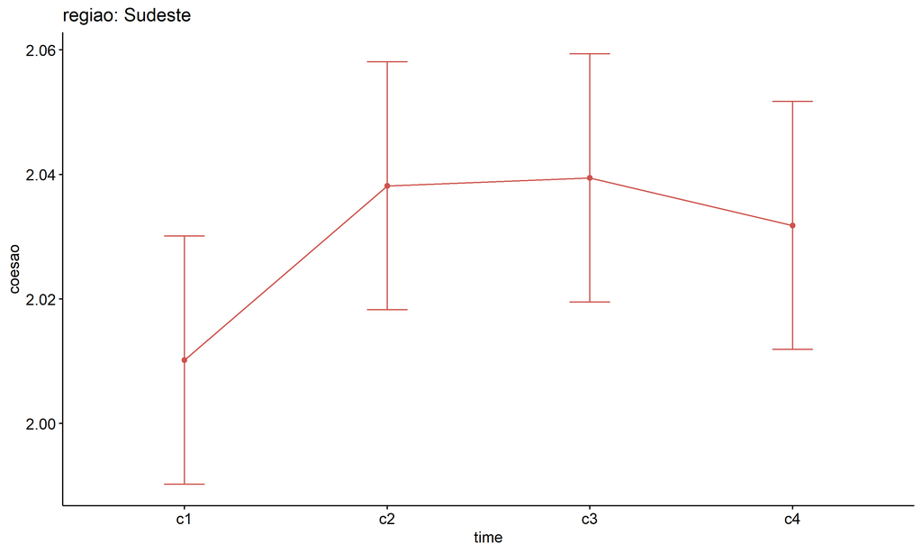

```r
emms.gg <- emms[which(emms$regiao == "Sudeste"),]
if (nrow(emms.gg) > 0)
  ggline(emms.gg, x = "time", y = "emmean", color = "#CD534CFF", ylab = "coesao") +
    geom_errorbar(aes(ymin = conf.low, ymax = conf.high),
                  width = 0.2, color = "#CD534CFF") +
    stat_pvalue_manual(
      add_xy_position(pwc[which(pwc$regiao == "Sudeste"),],
                      x = "time", fun = "mean_se"),
      hide.ns = T, color = "#CD534CFF", tip.length = F) +
    labs(title = "regiao: Sudeste")+
    theme(legend.text = element_blank())
```

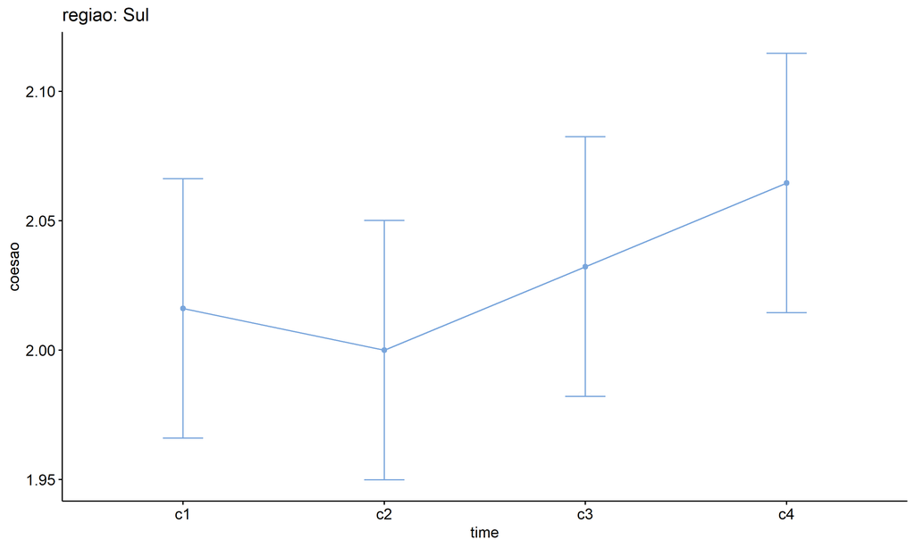

```r
emms.gg <- emms[which(emms$regiao == "Sul"),]
if (nrow(emms.gg) > 0)
  ggline(emms.gg, x = "time", y = "emmean", color = "#7AA6DCFF", ylab = "coesao") +
    geom_errorbar(aes(ymin = conf.low, ymax = conf.high),
                  width = 0.2, color = "#7AA6DCFF") +
    stat_pvalue_manual(
      add_xy_position(pwc[which(pwc$regiao == "Sul"),],
                      x = "time", fun = "mean_se"),
      hide.ns = T, color = "#7AA6DCFF", tip.length = F) +
    labs(title = "regiao: Sul")+
    theme(legend.text = element_blank())
```

## PairWise Computation after removing non.normal data

```r
if (length(non.ids) > 0)
  (pwc2 <- ldat2 %>% group_by(time) %>%
     emmeans_test(coesao ~ regiao, detailed = T, p.adjust.method = "bonferroni"))
```

```r
if (length(non.ids) > 0)
  (emms2 <- get_emmeans(pwc2))
```

```r
if (length(non.ids) > 0) {
  pwc2 <- add_xy_position(pwc2, x = "time", fun = "mean_se", dodge = 0.25)
  pd2 <- position_dodge(width = 0.25)

  ggline(emms2, x = "time", y = "emmean", color = "regiao",
         palette = c("#0073C2FF","#EFC000FF","#868686FF","#CD534CFF","#7AA6DCFF"),
         position = pd, ylab = "coesao") +
    geom_errorbar(aes(ymin = conf.low, ymax = conf.high, color = regiao),
                position = pd, width = 0.2) +
    stat_pvalue_manual(pwc2, hide.ns = T, tip.length = F, linetype = 1)
}
```

```r
if (length(non.ids) > 0)
  (pwc2 <- ldat2 %>% group_by(regiao) %>%
     emmeans_test(coesao ~ time, detailed = T, p.adjust.method = "bonferroni"))
```

```r
if (length(non.ids) > 0)
  (emms2 <- get_emmeans(pwc2))
```

```r
if (length(non.ids) > 0) {
  emms.gg <- emms2[which(emms2$regiao == "Centro-Oeste"),]
  if (nrow(emms.gg) > 0)
    ggline(emms.gg, x = "time", y = "emmean", color = "#0073C2FF", ylab = "coesao") +
    geom_errorbar(aes(ymin = conf.low, ymax = conf.high),
                  width = 0.2, color = "#0073C2FF") +
    stat_pvalue_manual(
      add_xy_position(pwc[which(pwc$regiao == "Centro-Oeste"),],
                      x = "time", fun = "mean_se"),
      hide.ns = T, color = "#0073C2FF", tip.length = F) +
    labs(title = "regiao: Centro-Oeste") +
    theme(legend.text = element_blank())
}
```

```r
if (length(non.ids) > 0) {
  emms.gg <- emms2[which(emms2$regiao == "Nordeste"),]
  if (nrow(emms.gg) > 0)
    ggline(emms.gg, x = "time", y = "emmean", color = "#EFC000FF", ylab = "coesao") +
    geom_errorbar(aes(ymin = conf.low, ymax = conf.high),
                  width = 0.2, color = "#EFC000FF") +
    stat_pvalue_manual(
      add_xy_position(pwc[which(pwc$regiao == "Nordeste"),],
                      x = "time", fun = "mean_se"),
      hide.ns = T, color = "#EFC000FF", tip.length = F) +
    labs(title = "regiao: Nordeste") +
    theme(legend.text = element_blank())
}
```

```r
if (length(non.ids) > 0) {
  emms.gg <- emms2[which(emms2$regiao == "Norte"),]
  if (nrow(emms.gg) > 0)
    ggline(emms.gg, x = "time", y = "emmean", color = "#868686FF", ylab = "coesao") +
    geom_errorbar(aes(ymin = conf.low, ymax = conf.high),
                  width = 0.2, color = "#868686FF") +
    stat_pvalue_manual(
      add_xy_position(pwc[which(pwc$regiao == "Norte"),],
                      x = "time", fun = "mean_se"),
      hide.ns = T, color = "#868686FF", tip.length = F) +
    labs(title = "regiao: Norte") +
    theme(legend.text = element_blank())
}
```

```r
if (length(non.ids) > 0) {
  emms.gg <- emms2[which(emms2$regiao == "Sudeste"),]
  if (nrow(emms.gg) > 0)
    ggline(emms.gg, x = "time", y = "emmean", color = "#CD534CFF", ylab = "coesao") +
    geom_errorbar(aes(ymin = conf.low, ymax = conf.high),
                  width = 0.2, color = "#CD534CFF") +
    stat_pvalue_manual(
      add_xy_position(pwc[which(pwc$regiao == "Sudeste"),],
                      x = "time", fun = "mean_se"),
      hide.ns = T, color = "#CD534CFF", tip.length = F) +
    labs(title = "regiao: Sudeste") +
    theme(legend.text = element_blank())
}
```

```r
if (length(non.ids) > 0) {
  emms.gg <- emms2[which(emms2$regiao == "Sul"),]
  if (nrow(emms.gg) > 0)
    ggline(emms.gg, x = "time", y = "emmean", color = "#7AA6DCFF", ylab = "coesao") +
    geom_errorbar(aes(ymin = conf.low, ymax = conf.high),
                  width = 0.2, color = "#7AA6DCFF") +
    stat_pvalue_manual(
      add_xy_position(pwc[which(pwc$regiao == "Sul"),],
                      x = "time", fun = "mean_se"),
      hide.ns = T, color = "#7AA6DCFF", tip.length = F) +
    labs(title = "regiao: Sul") +
    theme(legend.text = element_blank())
}
```

# ANOVA: coesao ~ time*porte + Error(id/time)

## Data Preparation

```r
data <- edat[,c("aluno_id","porte","ciclo","coesao")]
data <- data[data$ciclo %in% c("Primeiro Ciclo","Segundo Ciclo","Terceiro Ciclo","Quarto Ciclo"),]
data$ciclo <- factor(data$ciclo, c("Primeiro Ciclo","Segundo Ciclo","Terceiro Ciclo","Quarto Ciclo"))
data <- unique(data)

wdat <- spread(data, ciclo, coesao)
wdat <- wdat[complete.cases(wdat),]
colnames(wdat) <- c("id","porte","c1","c2","c3","c4")

ldat <- gather(wdat, key = time, value = coesao, c1,c2,c3,c4) %>%
  convert_as_factor(id, time)
ldat <- remove_group_data(ldat, "coesao", c("time", "porte"), n.limit = 30)
ldat$porte <- factor(ldat$porte, sort(unique(ldat$porte)))
```

### Check assumptions: Identifying Outliers

```r
outliers <- identify_outliers(group_by(ldat, time, porte), coesao)
(outliers <- outliers[outliers$is.extreme == T,])
```

```
## # A tibble: 50 × 6
##    porte                                       time  id                  coesao is.outlier is.extreme
##    <fct>                                       <fct> <fct>                <dbl> <lgl>      <lgl>
##  1 Entre 201 e 500 matrículas de escolarização c1    JRyGpNQA6mOEl1nzl1…      3 TRUE       TRUE
##  2 Entre 201 e 500 matrículas de escolarização c1    Kaj54imycuE0bbwH7x…      3 TRUE       TRUE
##  3 Entre 201 e 500 matrículas de escolarização c1    W8iXxSmW48zvfJyikM…      4 TRUE       TRUE
##  4 Entre 201 e 500 matrículas de escolarização c1    Y7HozU436KQ0wqdBGu…      4 TRUE       TRUE
##  5 Entre 51 e 200 matrículas de escolarização  c1    IZ2Xmfi9jueckwdzfk…      3 TRUE       TRUE
##  6 Entre 201 e 500 matrículas de escolarização c2    cuknOzzwN4oCRum5U5…      5 TRUE       TRUE
##  7 Entre 201 e 500 matrículas de escolarização c2    EqNpFnKTbLOWH4nmuu…      4 TRUE       TRUE
##  8 Entre 201 e 500 matrículas de escolarização c2    G4NIt8gEc7nfeQ9k2O…      4 TRUE       TRUE
##  9 Entre 201 e 500 matrículas de escolarização c2    HsQF2J0r79mHSWNe4l…      4 TRUE       TRUE
## 10 Entre 201 e 500 matrículas de escolarização c2    i5EZ8Ck9IgDueyMbw5…      3 TRUE       TRUE
## # ℹ 40 more rows
```

| porte | time | id | coesao | is.outlier | is.extreme |
| --- | --- | --- | --- | --- | --- |
| Entre 201 e 500 matrículas de escolarização | c1 | JRyGpNQA6mOEl1nzl1af | 3.0 | TRUE | TRUE |
| Entre 201 e 500 matrículas de escolarização | c1 | Kaj54imycuE0bbwH7xlD | 3.0 | TRUE | TRUE |
| Entre 201 e 500 matrículas de escolarização | c1 | W8iXxSmW48zvfJyikMZb | 4.0 | TRUE | TRUE |
| Entre 201 e 500 matrículas de escolarização | c1 | Y7HozU436KQ0wqdBGugu | 4.0 | TRUE | TRUE |
| Entre 51 e 200 matrículas de escolarização | c1 | IZ2Xmfi9jueckwdzfkiG | 3.0 | TRUE | TRUE |
| Entre 201 e 500 matrículas de escolarização | c2 | cuknOzzwN4oCRum5U5ph | 5.0 | TRUE | TRUE |
| Entre 201 e 500 matrículas de escolarização | c2 | EqNpFnKTbLOWH4nmuu6d | 4.0 | TRUE | TRUE |
| Entre 201 e 500 matrículas de escolarização | c2 | G4NIt8gEc7nfeQ9k2OkL | 4.0 | TRUE | TRUE |
| Entre 201 e 500 matrículas de escolarização | c2 | HsQF2J0r79mHSWNe4l6n | 4.0 | TRUE | TRUE |
| Entre 201 e 500 matrículas de escolarização | c2 | i5EZ8Ck9IgDueyMbw55v | 3.0 | TRUE | TRUE |
| Entre 201 e 500 matrículas de escolarização | c2 | j31LU8Xwm0EQ7Mihkhjj | 4.0 | TRUE | TRUE |
| Entre 201 e 500 matrículas de escolarização | c2 | oGUJyWRMYYbF9PNegJZh | 4.0 | TRUE | TRUE |
| Entre 201 e 500 matrículas de escolarização | c2 | qyt5dpIrCcmnZfDJIazf | 4.0 | TRUE | TRUE |
| Entre 201 e 500 matrículas de escolarização | c2 | W8iXxSmW48zvfJyikMZb | 4.0 | TRUE | TRUE |
| Entre 201 e 500 matrículas de escolarização | c2 | wQnhAn0Gfye5OP5zaTgh | 4.0 | TRUE | TRUE |
| Entre 201 e 500 matrículas de escolarização | c2 | wuumviqqlrNK6QzeoJPr | 4.0 | TRUE | TRUE |
| Entre 201 e 500 matrículas de escolarização | c2 | xk7eC5haTYuFQaJovsBZ | 4.0 | TRUE | TRUE |
| Entre 201 e 500 matrículas de escolarização | c2 | xQIlV1qQiNpzi4Bna9Ut | 4.0 | TRUE | TRUE |
| Entre 201 e 500 matrículas de escolarização | c2 | XxtCdGkKAnQOx88fyxk4 | 3.0 | TRUE | TRUE |
| Entre 201 e 500 matrículas de escolarização | c2 | YTYFFWzK4C7ejf1X1TUB | 4.0 | TRUE | TRUE |
| Entre 501 e 1000 matrículas de escolarização | c2 | G7bqQeqXmsQ3kiJNeYlz | 3.0 | TRUE | TRUE |
| Entre 501 e 1000 matrículas de escolarização | c2 | wgOGhRdGeAbGeHUAguQ5 | 5.0 | TRUE | TRUE |
| Entre 51 e 200 matrículas de escolarização | c2 | 0mGtUd2Axg2fjQmYZ4CC | 3.0 | TRUE | TRUE |
| Entre 201 e 500 matrículas de escolarização | c3 | CCVIt7MPeYMUOCCyBxPh | 4.0 | TRUE | TRUE |
| Entre 201 e 500 matrículas de escolarização | c3 | E3u63riyMFS8A2cNBnvC | 3.0 | TRUE | TRUE |
| Entre 201 e 500 matrículas de escolarização | c3 | EtUjsyq1GNevicwMDXlw | 3.5 | TRUE | TRUE |
| Entre 201 e 500 matrículas de escolarização | c3 | GN5vxU0haHKd9W22JGyk | 4.0 | TRUE | TRUE |
| Entre 201 e 500 matrículas de escolarização | c3 | HsQF2J0r79mHSWNe4l6n | 3.0 | TRUE | TRUE |
| Entre 201 e 500 matrículas de escolarização | c3 | i5EZ8Ck9IgDueyMbw55v | 5.0 | TRUE | TRUE |
| Entre 201 e 500 matrículas de escolarização | c3 | j31LU8Xwm0EQ7Mihkhjj | 4.0 | TRUE | TRUE |
| Entre 201 e 500 matrículas de escolarização | c3 | m5yRlxfIj73j4ossfTOB | 5.0 | TRUE | TRUE |
| Entre 201 e 500 matrículas de escolarização | c3 | OvwAQTWkdj8SYpPS8dgn | 4.0 | TRUE | TRUE |
| Entre 201 e 500 matrículas de escolarização | c3 | xk7eC5haTYuFQaJovsBZ | 4.0 | TRUE | TRUE |
| Entre 501 e 1000 matrículas de escolarização | c3 | 6bEKmKQpOuvY6PSQvzqj | 4.0 | TRUE | TRUE |
| Entre 501 e 1000 matrículas de escolarização | c3 | FkJFrnPezc8Ng4SSMx1z | 4.0 | TRUE | TRUE |
| Entre 501 e 1000 matrículas de escolarização | c3 | QAyx2z41ILLaMN0o7pjc | 3.0 | TRUE | TRUE |
| Entre 501 e 1000 matrículas de escolarização | c3 | TKvc4Eu2XaDXYPxuS7Qn | 4.0 | TRUE | TRUE |
| Entre 501 e 1000 matrículas de escolarização | c3 | u65Z834z75LDIy0slvaX | 5.0 | TRUE | TRUE |
| Entre 501 e 1000 matrículas de escolarização | c3 | vaOhaNww5ga5d9G6Cftj | 4.0 | TRUE | TRUE |
| Entre 51 e 200 matrículas de escolarização | c3 | PfTab7CnJIl6lys2Cxuq | 2.5 | TRUE | TRUE |
| Entre 201 e 500 matrículas de escolarização | c4 | 3DdYC9Dpykr9Mtg6YR91 | 4.0 | TRUE | TRUE |
| Entre 201 e 500 matrículas de escolarização | c4 | IMHqraVHK59KiF08zsGi | 3.5 | TRUE | TRUE |
| Entre 201 e 500 matrículas de escolarização | c4 | jVbbowshsqkUpPuGSIMu | 4.0 | TRUE | TRUE |
| Entre 201 e 500 matrículas de escolarização | c4 | VRWfIoYUFgdA8nGO5bpD | 4.0 | TRUE | TRUE |
| Entre 501 e 1000 matrículas de escolarização | c4 | 6bEKmKQpOuvY6PSQvzqj | 4.0 | TRUE | TRUE |
| Entre 501 e 1000 matrículas de escolarização | c4 | DP1fbT1lGhLiBnOFILLi | 4.0 | TRUE | TRUE |
| Entre 501 e 1000 matrículas de escolarização | c4 | zq67YfRtJ2g4hWPYAfkU | 3.0 | TRUE | TRUE |
| Entre 51 e 200 matrículas de escolarização | c4 | fgNBRPWfCa0TP4bDO8d2 | 4.0 | TRUE | TRUE |
| Entre 51 e 200 matrículas de escolarização | c4 | N7zTvCPK4nAUgH9eo3hg | 4.0 | TRUE | TRUE |
| Entre 51 e 200 matrículas de escolarização | c4 | tVMilOzYDlVoWwNezYUi | 4.0 | TRUE | TRUE |

### Check assumptions: Normality Test

```r
(normality.df <- normality.test.per.groups(ldat, "coesao", c("time", "porte")))
```

```
##       var variable time                                        porte   n skewness kurtosis symmetry
## 1  coesao   coesao   c1           Até 50 matrículas de escolarização  33 0.000000  0.00000 few data
## 2  coesao   coesao   c1  Entre 201 e 500 matrículas de escolarização 675 0.000000  0.00000 few data
## 3  coesao   coesao   c1 Entre 501 e 1000 matrículas de escolarização 249 0.000000  0.00000 few data
## 4  coesao   coesao   c1   Entre 51 e 200 matrículas de escolarização 162 0.000000  0.00000 few data
## 5  coesao   coesao   c2           Até 50 matrículas de escolarização  33 0.000000  0.00000 few data
## 6  coesao   coesao   c2  Entre 201 e 500 matrículas de escolarização 675 6.940003 48.28219       NO
## 7  coesao   coesao   c2 Entre 501 e 1000 matrículas de escolarização 249 0.000000  0.00000 few data
## 8  coesao   coesao   c2   Entre 51 e 200 matrículas de escolarização 162 0.000000  0.00000 few data
## 9  coesao   coesao   c3           Até 50 matrículas de escolarização  33 0.000000  0.00000 few data
## 10 coesao   coesao   c3  Entre 201 e 500 matrículas de escolarização 675 9.221688 89.09033       NO
## 11 coesao   coesao   c3 Entre 501 e 1000 matrículas de escolarização 249 6.888975 48.51806       NO
## 12 coesao   coesao   c3   Entre 51 e 200 matrículas de escolarização 162 0.000000  0.00000 few data
## 13 coesao   coesao   c4           Até 50 matrículas de escolarização  33 0.000000  0.00000 few data
## 14 coesao   coesao   c4  Entre 201 e 500 matrículas de escolarização 675 0.000000  0.00000 few data
```

[output cut: 19 more lines]

| var | variable | time | porte | n | skewness | kurtosis | symmetry | statistic | method | p | p.signif | normality |
| --- | --- | --- | --- | --- | --- | --- | --- | --- | --- | --- | --- | --- |
| coesao | coesao | c1 | Até 50 matrículas de escolarização | 33 | 0.000 | 0.000 | few data | NA | NA | 1 | NA | NO |
| coesao | coesao | c1 | Entre 201 e 500 matrículas de escolarização | 675 | 0.000 | 0.000 | few data | NA | NA | 1 | NA | NO |
| coesao | coesao | c1 | Entre 501 e 1000 matrículas de escolarização | 249 | 0.000 | 0.000 | few data | NA | NA | 1 | NA | NO |
| coesao | coesao | c1 | Entre 51 e 200 matrículas de escolarização | 162 | 0.000 | 0.000 | few data | NA | NA | 1 | NA | NO |
| coesao | coesao | c2 | Até 50 matrículas de escolarização | 33 | 0.000 | 0.000 | few data | NA | NA | 1 | NA | NO |
| coesao | coesao | c2 | Entre 201 e 500 matrículas de escolarização | 675 | 6.940 | 48.282 | NO | 877.065 | D’Agostino | 0 | **** | - |
| coesao | coesao | c2 | Entre 501 e 1000 matrículas de escolarização | 249 | 0.000 | 0.000 | few data | NA | NA | 1 | NA | NO |
| coesao | coesao | c2 | Entre 51 e 200 matrículas de escolarização | 162 | 0.000 | 0.000 | few data | NA | NA | 1 | NA | NO |
| coesao | coesao | c3 | Até 50 matrículas de escolarização | 33 | 0.000 | 0.000 | few data | NA | NA | 1 | NA | NO |
| coesao | coesao | c3 | Entre 201 e 500 matrículas de escolarização | 675 | 9.222 | 89.090 | NO | 1049.667 | D’Agostino | 0 | **** | - |
| coesao | coesao | c3 | Entre 501 e 1000 matrículas de escolarização | 249 | 6.889 | 48.518 | NO | 355.785 | D’Agostino | 0 | **** | - |
| coesao | coesao | c3 | Entre 51 e 200 matrículas de escolarização | 162 | 0.000 | 0.000 | few data | NA | NA | 1 | NA | NO |
| coesao | coesao | c4 | Até 50 matrículas de escolarização | 33 | 0.000 | 0.000 | few data | NA | NA | 1 | NA | NO |
| coesao | coesao | c4 | Entre 201 e 500 matrículas de escolarização | 675 | 0.000 | 0.000 | few data | NA | NA | 1 | NA | NO |
| coesao | coesao | c4 | Entre 501 e 1000 matrículas de escolarização | 249 | 0.000 | 0.000 | few data | NA | NA | 1 | NA | NO |
| coesao | coesao | c4 | Entre 51 e 200 matrículas de escolarização | 162 | 0.000 | 0.000 | few data | NA | NA | 1 | NA | NO |

```r
(non.ids <- unique(do.call(
  c, lapply(which(normality.df$normality == 'NO'), FUN = function(i) {
  idx = which(ldat$time == normality.df$time[i] &
                ldat$porte == normality.df$porte[i])
  getNonNormal(ldat$"coesao"[idx], ldat$id[idx])
}))))
```

```r
if (length(non.ids) > 0)
  ldat2 <- ldat[!ldat$id %in% non.ids,]
```

### Summary Statistics

```r
(sdat <- ldat %>% group_by(time, porte) %>%
   get_summary_stats(coesao, type = "mean_sd"))
```

```
## # A tibble: 16 × 6
##    porte                                        time  variable     n  mean    sd
##    <fct>                                        <fct> <fct>    <dbl> <dbl> <dbl>
##  1 Até 50 matrículas de escolarização           c1    coesao      33  2    0
##  2 Entre 201 e 500 matrículas de escolarização  c1    coesao     675  2.01 0.121
##  3 Entre 501 e 1000 matrículas de escolarização c1    coesao     249  2    0
##  4 Entre 51 e 200 matrículas de escolarização   c1    coesao     162  2.01 0.079
##  5 Até 50 matrículas de escolarização           c2    coesao      33  2    0
##  6 Entre 201 e 500 matrículas de escolarização  c2    coesao     675  2.04 0.293
##  7 Entre 501 e 1000 matrículas de escolarização c2    coesao     249  2.02 0.2
##  8 Entre 51 e 200 matrículas de escolarização   c2    coesao     162  2.01 0.079
##  9 Até 50 matrículas de escolarização           c3    coesao      33  2    0
## 10 Entre 201 e 500 matrículas de escolarização  c3    coesao     675  2.03 0.249
## 11 Entre 501 e 1000 matrículas de escolarização c3    coesao     249  2.05 0.32
## 12 Entre 51 e 200 matrículas de escolarização   c3    coesao     162  2.00 0.039
## 13 Até 50 matrículas de escolarização           c4    coesao      33  2    0
## 14 Entre 201 e 500 matrículas de escolarização  c4    coesao     675  2.01 0.145
## 15 Entre 501 e 1000 matrículas de escolarização c4    coesao     249  2.02 0.189
## 16 Entre 51 e 200 matrículas de escolarização   c4    coesao     162  2.04 0.27
```

| porte | time | variable | n | mean | sd |
| --- | --- | --- | --- | --- | --- |
| Até 50 matrículas de escolarização | c1 | coesao | 33 | 2.000 | 0.000 |
| Entre 201 e 500 matrículas de escolarização | c1 | coesao | 675 | 2.009 | 0.121 |
| Entre 501 e 1000 matrículas de escolarização | c1 | coesao | 249 | 2.000 | 0.000 |
| Entre 51 e 200 matrículas de escolarização | c1 | coesao | 162 | 2.006 | 0.079 |
| Até 50 matrículas de escolarização | c2 | coesao | 33 | 2.000 | 0.000 |
| Entre 201 e 500 matrículas de escolarização | c2 | coesao | 675 | 2.043 | 0.293 |
| Entre 501 e 1000 matrículas de escolarização | c2 | coesao | 249 | 2.016 | 0.200 |
| Entre 51 e 200 matrículas de escolarização | c2 | coesao | 162 | 2.006 | 0.079 |
| Até 50 matrículas de escolarização | c3 | coesao | 33 | 2.000 | 0.000 |
| Entre 201 e 500 matrículas de escolarização | c3 | coesao | 675 | 2.029 | 0.249 |
| Entre 501 e 1000 matrículas de escolarização | c3 | coesao | 249 | 2.048 | 0.320 |
| Entre 51 e 200 matrículas de escolarização | c3 | coesao | 162 | 2.003 | 0.039 |
| Até 50 matrículas de escolarização | c4 | coesao | 33 | 2.000 | 0.000 |
| Entre 201 e 500 matrículas de escolarização | c4 | coesao | 675 | 2.011 | 0.145 |
| Entre 501 e 1000 matrículas de escolarização | c4 | coesao | 249 | 2.020 | 0.189 |
| Entre 51 e 200 matrículas de escolarização | c4 | coesao | 162 | 2.037 | 0.270 |

```r
if (length(non.ids) > 0)
  (sdat <- ldat2 %>% group_by(time, porte) %>%
      get_summary_stats(coesao, type = "mean_sd"))
```

[output not shown]

## ANOVA Computation

```r
(res.aov <- anova_test(ldat, dv = coesao, wid = id, between = porte, within = time))
```

```
## ANOVA Table (type III tests)
##
## $ANOVA
##       Effect DFn  DFd    F     p p<.05      ges
## 1      porte   3 1115 0.73 0.534       0.000591
## 2       time   3 3345 0.52 0.668       0.000326
## 3 porte:time   9 3345 1.52 0.135       0.003000
##
## $`Mauchly's Test for Sphericity`
##       Effect    W                                                                       p p<.05
## 1       time 0.75 0.000000000000000000000000000000000000000000000000000000000000000000501     *
## 2 porte:time 0.75 0.000000000000000000000000000000000000000000000000000000000000000000501     *
##
## $`Sphericity Corrections`
##       Effect   GGe        DF[GG] p[GG] p[GG]<.05   HFe       DF[HF] p[HF] p[HF]<.05
## 1       time 0.874 2.62, 2924.18 0.644           0.876 2.63, 2931.7 0.644
## 2 porte:time 0.874 7.87, 2924.18 0.146           0.876 7.89, 2931.7 0.146
```

| Effect | DFn | DFd | F | p | p<.05 | ges |
| --- | --- | --- | --- | --- | --- | --- |
| porte | 3 | 1115 | 0.73 | 0.534 |  | 0.001 |
| time | 3 | 3345 | 0.52 | 0.668 |  | 0.000 |
| porte:time | 9 | 3345 | 1.52 | 0.135 |  | 0.003 |

| Effect | W | p | p<.05 |
| --- | --- | --- | --- |
| time | 0.75 | 0 | * |
| porte:time | 0.75 | 0 | * |

| Effect | GGe | DF[GG] | p[GG] | p[GG]<.05 | HFe | DF[HF] | p[HF] | p[HF]<.05 |
| --- | --- | --- | --- | --- | --- | --- | --- | --- |
| time | 0.874 | 2.62, 2924.18 | 0.644 |  | 0.876 | 2.63, 2931.7 | 0.644 |  |
| porte:time | 0.874 | 7.87, 2924.18 | 0.146 |  | 0.876 | 7.89, 2931.7 | 0.146 |  |

## ANOVA Computation after removing non.normal data

```r
if (length(non.ids) > 0)
  (res.aov2 <- anova_test(ldat2, dv = coesao, wid = id, between = porte , within = time))
```

## PairWise Computation

```r
(pwc <- ldat %>% group_by(time) %>%
   emmeans_test(coesao ~ porte, detailed = T, p.adjust.method = "bonferroni"))
```

```
## # A tibble: 24 × 15
##    time  term  .y.    group1    group2 null.value  estimate     se    df conf.low conf.high statistic
##  * <fct> <chr> <chr>  <chr>     <chr>       <dbl>     <dbl>  <dbl> <dbl>    <dbl>     <dbl>     <dbl>
##  1 c1    porte coesao Até 50 m… Entre…          0 -8.89e- 3 0.0360  4460 -0.0795     0.0617 -2.47e- 1
##  2 c1    porte coesao Até 50 m… Entre…          0  2.76e-15 0.0374  4460 -0.0733     0.0733  7.38e-14
##  3 c1    porte coesao Até 50 m… Entre…          0 -6.17e- 3 0.0386  4460 -0.0818     0.0694 -1.60e- 1
##  4 c1    porte coesao Entre 20… Entre…          0  8.89e- 3 0.0150  4460 -0.0205     0.0382  5.94e- 1
##  5 c1    porte coesao Entre 20… Entre…          0  2.72e- 3 0.0177  4460 -0.0319     0.0373  1.54e- 1
##  6 c1    porte coesao Entre 50… Entre…          0 -6.17e- 3 0.0204  4460 -0.0461     0.0338 -3.03e- 1
##  7 c2    porte coesao Até 50 m… Entre…          0 -4.30e- 2 0.0360  4460 -0.114      0.0276 -1.19e+ 0
##  8 c2    porte coesao Até 50 m… Entre…          0 -1.61e- 2 0.0374  4460 -0.0894     0.0573 -4.29e- 1
##  9 c2    porte coesao Até 50 m… Entre…          0 -6.17e- 3 0.0386  4460 -0.0818     0.0694 -1.60e- 1
## 10 c2    porte coesao Entre 20… Entre…          0  2.69e- 2 0.0150  4460 -0.00245    0.0562  1.80e+ 0
## # ℹ 14 more rows
## # ℹ 3 more variables: p <dbl>, p.adj <dbl>, p.adj.signif <chr>
```

| time | term | .y. | group1 | group2 | null.value | estimate | se | df | conf.low | conf.high | statistic | p | p.adj | p.adj.signif |
| --- | --- | --- | --- | --- | --- | --- | --- | --- | --- | --- | --- | --- | --- | --- |
| c1 | porte | coesao | Até 50 matrículas de escolarização | Entre 201 e 500 matrículas de escolarização | 0 | -0.009 | 0.036 | 4460 | -0.079 | 0.062 | -0.247 | 0.805 | 1.000 | ns |
| c1 | porte | coesao | Até 50 matrículas de escolarização | Entre 501 e 1000 matrículas de escolarização | 0 | 0.000 | 0.037 | 4460 | -0.073 | 0.073 | 0.000 | 1.000 | 1.000 | ns |
| c1 | porte | coesao | Até 50 matrículas de escolarização | Entre 51 e 200 matrículas de escolarização | 0 | -0.006 | 0.039 | 4460 | -0.082 | 0.069 | -0.160 | 0.873 | 1.000 | ns |
| c1 | porte | coesao | Entre 201 e 500 matrículas de escolarização | Entre 501 e 1000 matrículas de escolarização | 0 | 0.009 | 0.015 | 4460 | -0.020 | 0.038 | 0.594 | 0.553 | 1.000 | ns |
| c1 | porte | coesao | Entre 201 e 500 matrículas de escolarização | Entre 51 e 200 matrículas de escolarização | 0 | 0.003 | 0.018 | 4460 | -0.032 | 0.037 | 0.154 | 0.878 | 1.000 | ns |
| c1 | porte | coesao | Entre 501 e 1000 matrículas de escolarização | Entre 51 e 200 matrículas de escolarização | 0 | -0.006 | 0.020 | 4460 | -0.046 | 0.034 | -0.303 | 0.762 | 1.000 | ns |
| c2 | porte | coesao | Até 50 matrículas de escolarização | Entre 201 e 500 matrículas de escolarização | 0 | -0.043 | 0.036 | 4460 | -0.114 | 0.028 | -1.194 | 0.233 | 1.000 | ns |
| c2 | porte | coesao | Até 50 matrículas de escolarização | Entre 501 e 1000 matrículas de escolarização | 0 | -0.016 | 0.037 | 4460 | -0.089 | 0.057 | -0.429 | 0.668 | 1.000 | ns |
| c2 | porte | coesao | Até 50 matrículas de escolarização | Entre 51 e 200 matrículas de escolarização | 0 | -0.006 | 0.039 | 4460 | -0.082 | 0.069 | -0.160 | 0.873 | 1.000 | ns |
| c2 | porte | coesao | Entre 201 e 500 matrículas de escolarização | Entre 501 e 1000 matrículas de escolarização | 0 | 0.027 | 0.015 | 4460 | -0.002 | 0.056 | 1.797 | 0.072 | 0.435 | ns |
| c2 | porte | coesao | Entre 201 e 500 matrículas de escolarização | Entre 51 e 200 matrículas de escolarização | 0 | 0.037 | 0.018 | 4460 | 0.002 | 0.071 | 2.083 | 0.037 | 0.224 | ns |
| c2 | porte | coesao | Entre 501 e 1000 matrículas de escolarização | Entre 51 e 200 matrículas de escolarização | 0 | 0.010 | 0.020 | 4460 | -0.030 | 0.050 | 0.485 | 0.627 | 1.000 | ns |
| c3 | porte | coesao | Até 50 matrículas de escolarização | Entre 201 e 500 matrículas de escolarização | 0 | -0.029 | 0.036 | 4460 | -0.099 | 0.042 | -0.803 | 0.422 | 1.000 | ns |
| c3 | porte | coesao | Até 50 matrículas de escolarização | Entre 501 e 1000 matrículas de escolarização | 0 | -0.048 | 0.037 | 4460 | -0.122 | 0.025 | -1.288 | 0.198 | 1.000 | ns |
| c3 | porte | coesao | Até 50 matrículas de escolarização | Entre 51 e 200 matrículas de escolarização | 0 | -0.003 | 0.039 | 4460 | -0.079 | 0.073 | -0.080 | 0.936 | 1.000 | ns |
| c3 | porte | coesao | Entre 201 e 500 matrículas de escolarização | Entre 501 e 1000 matrículas de escolarização | 0 | -0.019 | 0.015 | 4460 | -0.049 | 0.010 | -1.289 | 0.197 | 1.000 | ns |
| c3 | porte | coesao | Entre 201 e 500 matrículas de escolarização | Entre 51 e 200 matrículas de escolarização | 0 | 0.026 | 0.018 | 4460 | -0.009 | 0.060 | 1.461 | 0.144 | 0.865 | ns |
| c3 | porte | coesao | Entre 501 e 1000 matrículas de escolarização | Entre 51 e 200 matrículas de escolarização | 0 | 0.045 | 0.020 | 4460 | 0.005 | 0.085 | 2.213 | 0.027 | 0.162 | ns |
| c4 | porte | coesao | Até 50 matrículas de escolarização | Entre 201 e 500 matrículas de escolarização | 0 | -0.011 | 0.036 | 4460 | -0.082 | 0.059 | -0.309 | 0.758 | 1.000 | ns |
| c4 | porte | coesao | Até 50 matrículas de escolarização | Entre 501 e 1000 matrículas de escolarização | 0 | -0.020 | 0.037 | 4460 | -0.093 | 0.053 | -0.537 | 0.591 | 1.000 | ns |
| c4 | porte | coesao | Até 50 matrículas de escolarização | Entre 51 e 200 matrículas de escolarização | 0 | -0.037 | 0.039 | 4460 | -0.113 | 0.039 | -0.960 | 0.337 | 1.000 | ns |
| c4 | porte | coesao | Entre 201 e 500 matrículas de escolarização | Entre 501 e 1000 matrículas de escolarização | 0 | -0.009 | 0.015 | 4460 | -0.038 | 0.020 | -0.599 | 0.549 | 1.000 | ns |
| c4 | porte | coesao | Entre 201 e 500 matrículas de escolarização | Entre 51 e 200 matrículas de escolarização | 0 | -0.026 | 0.018 | 4460 | -0.061 | 0.009 | -1.468 | 0.142 | 0.854 | ns |
| c4 | porte | coesao | Entre 501 e 1000 matrículas de escolarização | Entre 51 e 200 matrículas de escolarização | 0 | -0.017 | 0.020 | 4460 | -0.057 | 0.023 | -0.832 | 0.405 | 1.000 | ns |

```r
(emms <- get_emmeans(pwc))
```

```
## # A tibble: 16 × 8
##    time  porte                                        emmean      se    df conf.low conf.high method
##    <fct> <fct>                                         <dbl>   <dbl> <dbl>    <dbl>     <dbl> <chr>
##  1 c1    Até 50 matrículas de escolarização             2.00 0.0351   4460     1.93      2.07 Emmean…
##  2 c1    Entre 201 e 500 matrículas de escolarização    2.01 0.00777  4460     1.99      2.02 Emmean…
##  3 c1    Entre 501 e 1000 matrículas de escolarização   2.00 0.0128   4460     1.97      2.03 Emmean…
##  4 c1    Entre 51 e 200 matrículas de escolarização     2.01 0.0159   4460     1.98      2.04 Emmean…
##  5 c2    Até 50 matrículas de escolarização             2.00 0.0351   4460     1.93      2.07 Emmean…
##  6 c2    Entre 201 e 500 matrículas de escolarização    2.04 0.00777  4460     2.03      2.06 Emmean…
##  7 c2    Entre 501 e 1000 matrículas de escolarização   2.02 0.0128   4460     1.99      2.04 Emmean…
##  8 c2    Entre 51 e 200 matrículas de escolarização     2.01 0.0159   4460     1.98      2.04 Emmean…
##  9 c3    Até 50 matrículas de escolarização             2.00 0.0351   4460     1.93      2.07 Emmean…
## 10 c3    Entre 201 e 500 matrículas de escolarização    2.03 0.00777  4460     2.01      2.04 Emmean…
## 11 c3    Entre 501 e 1000 matrículas de escolarização   2.05 0.0128   4460     2.02      2.07 Emmean…
## 12 c3    Entre 51 e 200 matrículas de escolarização     2.00 0.0159   4460     1.97      2.03 Emmean…
## 13 c4    Até 50 matrículas de escolarização             2.00 0.0351   4460     1.93      2.07 Emmean…
## 14 c4    Entre 201 e 500 matrículas de escolarização    2.01 0.00777  4460     2.00      2.03 Emmean…
## 15 c4    Entre 501 e 1000 matrículas de escolarização   2.02 0.0128   4460     1.99      2.05 Emmean…
## 16 c4    Entre 51 e 200 matrículas de escolarização     2.04 0.0159   4460     2.01      2.07 Emmean…
```

| time | porte | emmean | se | df | conf.low | conf.high | method |
| --- | --- | --- | --- | --- | --- | --- | --- |
| c1 | Até 50 matrículas de escolarização | 2.000 | 0.035 | 4460 | 1.931 | 2.069 | Emmeans test |
| c1 | Entre 201 e 500 matrículas de escolarização | 2.009 | 0.008 | 4460 | 1.994 | 2.024 | Emmeans test |
| c1 | Entre 501 e 1000 matrículas de escolarização | 2.000 | 0.013 | 4460 | 1.975 | 2.025 | Emmeans test |
| c1 | Entre 51 e 200 matrículas de escolarização | 2.006 | 0.016 | 4460 | 1.975 | 2.037 | Emmeans test |
| c2 | Até 50 matrículas de escolarização | 2.000 | 0.035 | 4460 | 1.931 | 2.069 | Emmeans test |
| c2 | Entre 201 e 500 matrículas de escolarização | 2.043 | 0.008 | 4460 | 2.028 | 2.058 | Emmeans test |
| c2 | Entre 501 e 1000 matrículas de escolarização | 2.016 | 0.013 | 4460 | 1.991 | 2.041 | Emmeans test |
| c2 | Entre 51 e 200 matrículas de escolarização | 2.006 | 0.016 | 4460 | 1.975 | 2.037 | Emmeans test |
| c3 | Até 50 matrículas de escolarização | 2.000 | 0.035 | 4460 | 1.931 | 2.069 | Emmeans test |
| c3 | Entre 201 e 500 matrículas de escolarização | 2.029 | 0.008 | 4460 | 2.014 | 2.044 | Emmeans test |
| c3 | Entre 501 e 1000 matrículas de escolarização | 2.048 | 0.013 | 4460 | 2.023 | 2.073 | Emmeans test |
| c3 | Entre 51 e 200 matrículas de escolarização | 2.003 | 0.016 | 4460 | 1.972 | 2.034 | Emmeans test |
| c4 | Até 50 matrículas de escolarização | 2.000 | 0.035 | 4460 | 1.931 | 2.069 | Emmeans test |
| c4 | Entre 201 e 500 matrículas de escolarização | 2.011 | 0.008 | 4460 | 1.996 | 2.026 | Emmeans test |
| c4 | Entre 501 e 1000 matrículas de escolarização | 2.020 | 0.013 | 4460 | 1.995 | 2.045 | Emmeans test |
| c4 | Entre 51 e 200 matrículas de escolarização | 2.037 | 0.016 | 4460 | 2.006 | 2.068 | Emmeans test |

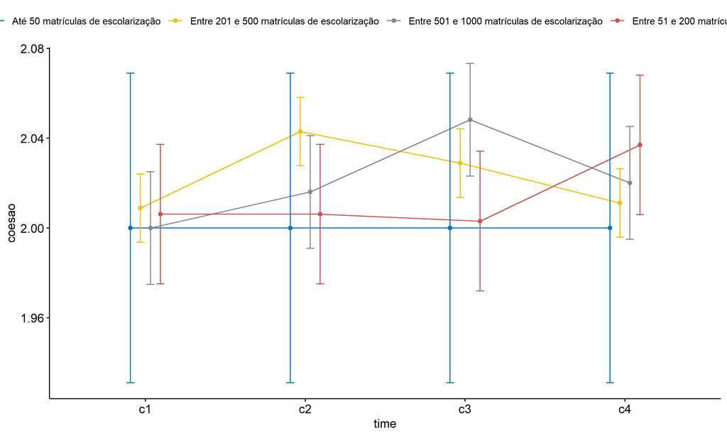

```r
pwc <- add_xy_position(pwc, x = "time", fun = "mean_se", dodge = 0.25)
pd <- position_dodge(width = 0.25)
ggline(emms, x = "time", y = "emmean", color = "porte",
       palette = c("#0073C2FF","#EFC000FF","#868686FF","#CD534CFF","#7AA6DCFF"),
       position = pd, ylab = "coesao") +
  geom_errorbar(aes(ymin = conf.low, ymax = conf.high, color = porte),
                position = pd, width = 0.2) +
  stat_pvalue_manual(pwc, hide.ns = T, tip.length = F, linetype = 1)
```

```r
(pwc <- ldat %>% group_by(porte) %>%
    emmeans_test(coesao ~ time, detailed = T, p.adjust.method = "bonferroni"))
```

```
## # A tibble: 24 × 15
##    porte     term  .y.   group1 group2 null.value  estimate     se    df conf.low conf.high statistic
##  * <fct>     <chr> <chr> <chr>  <chr>       <dbl>     <dbl>  <dbl> <dbl>    <dbl>     <dbl>     <dbl>
##  1 Até 50 m… time  coes… c1     c2              0  2.60e-17 0.0497  4460 -0.0975    0.0975   5.22e-16
##  2 Até 50 m… time  coes… c1     c3              0 -1.66e-15 0.0497  4460 -0.0975    0.0975  -3.34e-14
##  3 Até 50 m… time  coes… c1     c4              0 -1.02e-15 0.0497  4460 -0.0975    0.0975  -2.06e-14
##  4 Até 50 m… time  coes… c2     c3              0 -1.69e-15 0.0497  4460 -0.0975    0.0975  -3.39e-14
##  5 Até 50 m… time  coes… c2     c4              0 -1.05e-15 0.0497  4460 -0.0975    0.0975  -2.11e-14
##  6 Até 50 m… time  coes… c3     c4              0  6.37e-16 0.0497  4460 -0.0975    0.0975   1.28e-14
##  7 Entre 20… time  coes… c1     c2              0 -3.41e- 2 0.0110  4460 -0.0556   -0.0125  -3.10e+ 0
##  8 Entre 20… time  coes… c1     c3              0 -2.00e- 2 0.0110  4460 -0.0415    0.00155 -1.82e+ 0
##  9 Entre 20… time  coes… c1     c4              0 -2.22e- 3 0.0110  4460 -0.0238    0.0193  -2.02e- 1
## 10 Entre 20… time  coes… c2     c3              0  1.41e- 2 0.0110  4460 -0.00747   0.0356   1.28e+ 0
## # ℹ 14 more rows
## # ℹ 3 more variables: p <dbl>, p.adj <dbl>, p.adj.signif <chr>
```

| porte | term | .y. | group1 | group2 | null.value | estimate | se | df | conf.low | conf.high | statistic | p | p.adj | p.adj.signif |
| --- | --- | --- | --- | --- | --- | --- | --- | --- | --- | --- | --- | --- | --- | --- |
| Até 50 matrículas de escolarização | time | coesao | c1 | c2 | 0 | 0.000 | 0.050 | 4460 | -0.097 | 0.097 | 0.000 | 1.000 | 1.000 | ns |
| Até 50 matrículas de escolarização | time | coesao | c1 | c3 | 0 | 0.000 | 0.050 | 4460 | -0.097 | 0.097 | 0.000 | 1.000 | 1.000 | ns |
| Até 50 matrículas de escolarização | time | coesao | c1 | c4 | 0 | 0.000 | 0.050 | 4460 | -0.097 | 0.097 | 0.000 | 1.000 | 1.000 | ns |
| Até 50 matrículas de escolarização | time | coesao | c2 | c3 | 0 | 0.000 | 0.050 | 4460 | -0.097 | 0.097 | 0.000 | 1.000 | 1.000 | ns |
| Até 50 matrículas de escolarização | time | coesao | c2 | c4 | 0 | 0.000 | 0.050 | 4460 | -0.097 | 0.097 | 0.000 | 1.000 | 1.000 | ns |
| Até 50 matrículas de escolarização | time | coesao | c3 | c4 | 0 | 0.000 | 0.050 | 4460 | -0.097 | 0.097 | 0.000 | 1.000 | 1.000 | ns |
| Entre 201 e 500 matrículas de escolarização | time | coesao | c1 | c2 | 0 | -0.034 | 0.011 | 4460 | -0.056 | -0.013 | -3.100 | 0.002 | 0.012 | * |
| Entre 201 e 500 matrículas de escolarização | time | coesao | c1 | c3 | 0 | -0.020 | 0.011 | 4460 | -0.042 | 0.002 | -1.820 | 0.069 | 0.413 | ns |
| Entre 201 e 500 matrículas de escolarização | time | coesao | c1 | c4 | 0 | -0.002 | 0.011 | 4460 | -0.024 | 0.019 | -0.202 | 0.840 | 1.000 | ns |
| Entre 201 e 500 matrículas de escolarização | time | coesao | c2 | c3 | 0 | 0.014 | 0.011 | 4460 | -0.007 | 0.036 | 1.281 | 0.200 | 1.000 | ns |
| Entre 201 e 500 matrículas de escolarização | time | coesao | c2 | c4 | 0 | 0.032 | 0.011 | 4460 | 0.010 | 0.053 | 2.898 | 0.004 | 0.023 | * |
| Entre 201 e 500 matrículas de escolarização | time | coesao | c3 | c4 | 0 | 0.018 | 0.011 | 4460 | -0.004 | 0.039 | 1.618 | 0.106 | 0.635 | ns |
| Entre 501 e 1000 matrículas de escolarização | time | coesao | c1 | c2 | 0 | -0.016 | 0.018 | 4460 | -0.052 | 0.019 | -0.888 | 0.375 | 1.000 | ns |
| Entre 501 e 1000 matrículas de escolarização | time | coesao | c1 | c3 | 0 | -0.048 | 0.018 | 4460 | -0.084 | -0.013 | -2.663 | 0.008 | 0.047 | * |
| Entre 501 e 1000 matrículas de escolarização | time | coesao | c1 | c4 | 0 | -0.020 | 0.018 | 4460 | -0.056 | 0.015 | -1.110 | 0.267 | 1.000 | ns |
| Entre 501 e 1000 matrículas de escolarização | time | coesao | c2 | c3 | 0 | -0.032 | 0.018 | 4460 | -0.068 | 0.003 | -1.775 | 0.076 | 0.455 | ns |
| Entre 501 e 1000 matrículas de escolarização | time | coesao | c2 | c4 | 0 | -0.004 | 0.018 | 4460 | -0.039 | 0.031 | -0.222 | 0.824 | 1.000 | ns |
| Entre 501 e 1000 matrículas de escolarização | time | coesao | c3 | c4 | 0 | 0.028 | 0.018 | 4460 | -0.007 | 0.064 | 1.554 | 0.120 | 0.722 | ns |
| Entre 51 e 200 matrículas de escolarização | time | coesao | c1 | c2 | 0 | 0.000 | 0.022 | 4460 | -0.044 | 0.044 | 0.000 | 1.000 | 1.000 | ns |
| Entre 51 e 200 matrículas de escolarização | time | coesao | c1 | c3 | 0 | 0.003 | 0.022 | 4460 | -0.041 | 0.047 | 0.138 | 0.891 | 1.000 | ns |
| Entre 51 e 200 matrículas de escolarização | time | coesao | c1 | c4 | 0 | -0.031 | 0.022 | 4460 | -0.075 | 0.013 | -1.376 | 0.169 | 1.000 | ns |
| Entre 51 e 200 matrículas de escolarização | time | coesao | c2 | c3 | 0 | 0.003 | 0.022 | 4460 | -0.041 | 0.047 | 0.138 | 0.891 | 1.000 | ns |
| Entre 51 e 200 matrículas de escolarização | time | coesao | c2 | c4 | 0 | -0.031 | 0.022 | 4460 | -0.075 | 0.013 | -1.376 | 0.169 | 1.000 | ns |
| Entre 51 e 200 matrículas de escolarização | time | coesao | c3 | c4 | 0 | -0.034 | 0.022 | 4460 | -0.078 | 0.010 | -1.513 | 0.130 | 0.782 | ns |

```r
(emms <- get_emmeans(pwc))
```

```
## # A tibble: 16 × 8
##    porte                                        time  emmean      se    df conf.low conf.high method
##    <fct>                                        <fct>  <dbl>   <dbl> <dbl>    <dbl>     <dbl> <chr>
##  1 Até 50 matrículas de escolarização           c1      2.00 0.0351   4460     1.93      2.07 Emmean…
##  2 Até 50 matrículas de escolarização           c2      2.00 0.0351   4460     1.93      2.07 Emmean…
##  3 Até 50 matrículas de escolarização           c3      2.00 0.0351   4460     1.93      2.07 Emmean…
##  4 Até 50 matrículas de escolarização           c4      2.00 0.0351   4460     1.93      2.07 Emmean…
##  5 Entre 201 e 500 matrículas de escolarização  c1      2.01 0.00777  4460     1.99      2.02 Emmean…
##  6 Entre 201 e 500 matrículas de escolarização  c2      2.04 0.00777  4460     2.03      2.06 Emmean…
##  7 Entre 201 e 500 matrículas de escolarização  c3      2.03 0.00777  4460     2.01      2.04 Emmean…
##  8 Entre 201 e 500 matrículas de escolarização  c4      2.01 0.00777  4460     2.00      2.03 Emmean…
##  9 Entre 501 e 1000 matrículas de escolarização c1      2.00 0.0128   4460     1.97      2.03 Emmean…
## 10 Entre 501 e 1000 matrículas de escolarização c2      2.02 0.0128   4460     1.99      2.04 Emmean…
## 11 Entre 501 e 1000 matrículas de escolarização c3      2.05 0.0128   4460     2.02      2.07 Emmean…
## 12 Entre 501 e 1000 matrículas de escolarização c4      2.02 0.0128   4460     1.99      2.05 Emmean…
## 13 Entre 51 e 200 matrículas de escolarização   c1      2.01 0.0159   4460     1.98      2.04 Emmean…
## 14 Entre 51 e 200 matrículas de escolarização   c2      2.01 0.0159   4460     1.98      2.04 Emmean…
## 15 Entre 51 e 200 matrículas de escolarização   c3      2.00 0.0159   4460     1.97      2.03 Emmean…
## 16 Entre 51 e 200 matrículas de escolarização   c4      2.04 0.0159   4460     2.01      2.07 Emmean…
```

| porte | time | emmean | se | df | conf.low | conf.high | method |
| --- | --- | --- | --- | --- | --- | --- | --- |
| Até 50 matrículas de escolarização | c1 | 2.000 | 0.035 | 4460 | 1.931 | 2.069 | Emmeans test |
| Até 50 matrículas de escolarização | c2 | 2.000 | 0.035 | 4460 | 1.931 | 2.069 | Emmeans test |
| Até 50 matrículas de escolarização | c3 | 2.000 | 0.035 | 4460 | 1.931 | 2.069 | Emmeans test |
| Até 50 matrículas de escolarização | c4 | 2.000 | 0.035 | 4460 | 1.931 | 2.069 | Emmeans test |
| Entre 201 e 500 matrículas de escolarização | c1 | 2.009 | 0.008 | 4460 | 1.994 | 2.024 | Emmeans test |
| Entre 201 e 500 matrículas de escolarização | c2 | 2.043 | 0.008 | 4460 | 2.028 | 2.058 | Emmeans test |
| Entre 201 e 500 matrículas de escolarização | c3 | 2.029 | 0.008 | 4460 | 2.014 | 2.044 | Emmeans test |
| Entre 201 e 500 matrículas de escolarização | c4 | 2.011 | 0.008 | 4460 | 1.996 | 2.026 | Emmeans test |
| Entre 501 e 1000 matrículas de escolarização | c1 | 2.000 | 0.013 | 4460 | 1.975 | 2.025 | Emmeans test |
| Entre 501 e 1000 matrículas de escolarização | c2 | 2.016 | 0.013 | 4460 | 1.991 | 2.041 | Emmeans test |
| Entre 501 e 1000 matrículas de escolarização | c3 | 2.048 | 0.013 | 4460 | 2.023 | 2.073 | Emmeans test |
| Entre 501 e 1000 matrículas de escolarização | c4 | 2.020 | 0.013 | 4460 | 1.995 | 2.045 | Emmeans test |
| Entre 51 e 200 matrículas de escolarização | c1 | 2.006 | 0.016 | 4460 | 1.975 | 2.037 | Emmeans test |
| Entre 51 e 200 matrículas de escolarização | c2 | 2.006 | 0.016 | 4460 | 1.975 | 2.037 | Emmeans test |
| Entre 51 e 200 matrículas de escolarização | c3 | 2.003 | 0.016 | 4460 | 1.972 | 2.034 | Emmeans test |
| Entre 51 e 200 matrículas de escolarização | c4 | 2.037 | 0.016 | 4460 | 2.006 | 2.068 | Emmeans test |

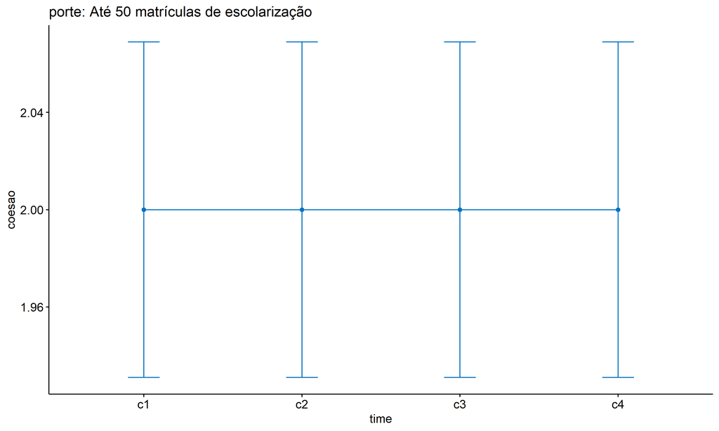

```r
emms.gg <- emms[which(emms$porte == "Até 50 matrículas de escolarização"),]
if (nrow(emms.gg) > 0)
  ggline(emms.gg, x = "time", y = "emmean", color = "#0073C2FF", ylab = "coesao") +
    geom_errorbar(aes(ymin = conf.low, ymax = conf.high),
                  width = 0.2, color = "#0073C2FF") +
    stat_pvalue_manual(
      add_xy_position(pwc[which(pwc$porte == "Até 50 matrículas de escolarização"),],
                      x = "time", fun = "mean_se"),
      hide.ns = T, color = "#0073C2FF", tip.length = F) +
    labs(title = "porte: Até 50 matrículas de escolarização")+
    theme(legend.text = element_blank())
```

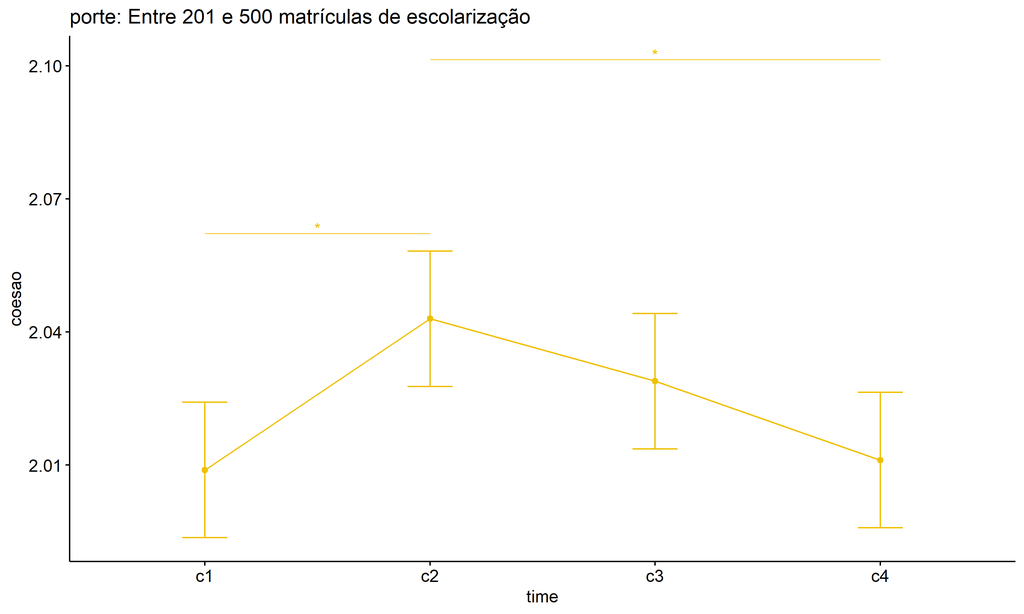

```r
emms.gg <- emms[which(emms$porte == "Entre 201 e 500 matrículas de escolarização"),]
if (nrow(emms.gg) > 0)
  ggline(emms.gg, x = "time", y = "emmean", color = "#EFC000FF", ylab = "coesao") +
    geom_errorbar(aes(ymin = conf.low, ymax = conf.high),
                  width = 0.2, color = "#EFC000FF") +
    stat_pvalue_manual(
      add_xy_position(pwc[which(pwc$porte == "Entre 201 e 500 matrículas de escolarização"),],
                      x = "time", fun = "mean_se"),
      hide.ns = T, color = "#EFC000FF", tip.length = F) +
    labs(title = "porte: Entre 201 e 500 matrículas de escolarização")+
    theme(legend.text = element_blank())
```

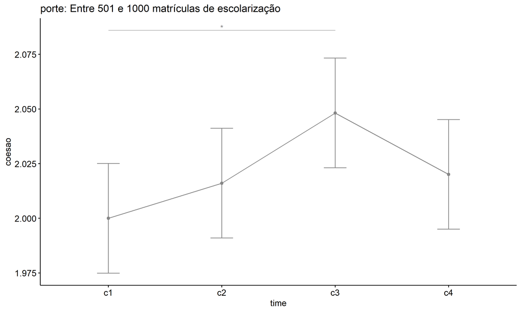

```r
emms.gg <- emms[which(emms$porte == "Entre 501 e 1000 matrículas de escolarização"),]
if (nrow(emms.gg) > 0)
  ggline(emms.gg, x = "time", y = "emmean", color = "#868686FF", ylab = "coesao") +
    geom_errorbar(aes(ymin = conf.low, ymax = conf.high),
                  width = 0.2, color = "#868686FF") +
    stat_pvalue_manual(
      add_xy_position(pwc[which(pwc$porte == "Entre 501 e 1000 matrículas de escolarização"),],
                      x = "time", fun = "mean_se"),
      hide.ns = T, color = "#868686FF", tip.length = F) +
    labs(title = "porte: Entre 501 e 1000 matrículas de escolarização")+
    theme(legend.text = element_blank())
```

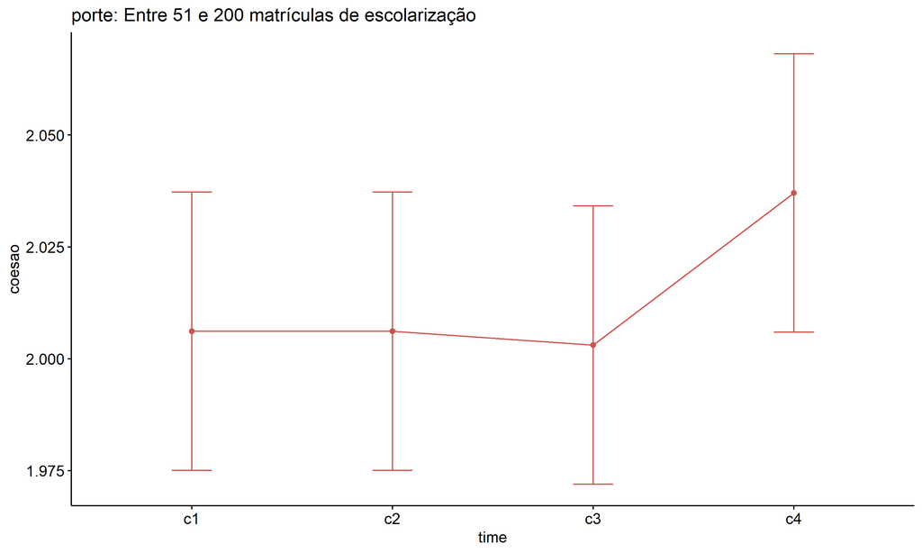

```r
emms.gg <- emms[which(emms$porte == "Entre 51 e 200 matrículas de escolarização"),]
if (nrow(emms.gg) > 0)
  ggline(emms.gg, x = "time", y = "emmean", color = "#CD534CFF", ylab = "coesao") +
    geom_errorbar(aes(ymin = conf.low, ymax = conf.high),
                  width = 0.2, color = "#CD534CFF") +
    stat_pvalue_manual(
      add_xy_position(pwc[which(pwc$porte == "Entre 51 e 200 matrículas de escolarização"),],
                      x = "time", fun = "mean_se"),
      hide.ns = T, color = "#CD534CFF", tip.length = F) +
    labs(title = "porte: Entre 51 e 200 matrículas de escolarização")+
    theme(legend.text = element_blank())
```

```r
emms.gg <- emms[which(emms$porte == "Mais de 1000 matrículas de escolarização"),]
if (nrow(emms.gg) > 0)
  ggline(emms.gg, x = "time", y = "emmean", color = "#7AA6DCFF", ylab = "coesao") +
    geom_errorbar(aes(ymin = conf.low, ymax = conf.high),
                  width = 0.2, color = "#7AA6DCFF") +
    stat_pvalue_manual(
      add_xy_position(pwc[which(pwc$porte == "Mais de 1000 matrículas de escolarização"),],
                      x = "time", fun = "mean_se"),
      hide.ns = T, color = "#7AA6DCFF", tip.length = F) +
    labs(title = "porte: Mais de 1000 matrículas de escolarização")+
    theme(legend.text = element_blank())
```

## PairWise Computation after removing non.normal data

```r
if (length(non.ids) > 0)
  (pwc2 <- ldat2 %>% group_by(time) %>%
     emmeans_test(coesao ~ porte, detailed = T, p.adjust.method = "bonferroni"))
```

```r
if (length(non.ids) > 0)
  (emms2 <- get_emmeans(pwc2))
```

```r
if (length(non.ids) > 0) {
  pwc2 <- add_xy_position(pwc2, x = "time", fun = "mean_se", dodge = 0.25)
  pd2 <- position_dodge(width = 0.25)

  ggline(emms2, x = "time", y = "emmean", color = "porte",
         palette = c("#0073C2FF","#EFC000FF","#868686FF","#CD534CFF","#7AA6DCFF"),
         position = pd, ylab = "coesao") +
    geom_errorbar(aes(ymin = conf.low, ymax = conf.high, color = porte),
                position = pd, width = 0.2) +
    stat_pvalue_manual(pwc2, hide.ns = T, tip.length = F, linetype = 1)
}
```

```r
if (length(non.ids) > 0)
  (pwc2 <- ldat2 %>% group_by(porte) %>%
     emmeans_test(coesao ~ time, detailed = T, p.adjust.method = "bonferroni"))
```

```r
if (length(non.ids) > 0)
  (emms2 <- get_emmeans(pwc2))
```

```r
if (length(non.ids) > 0) {
  emms.gg <- emms2[which(emms2$porte == "Até 50 matrículas de escolarização"),]
  if (nrow(emms.gg) > 0)
    ggline(emms.gg, x = "time", y = "emmean", color = "#0073C2FF", ylab = "coesao") +
    geom_errorbar(aes(ymin = conf.low, ymax = conf.high),
                  width = 0.2, color = "#0073C2FF") +
    stat_pvalue_manual(
      add_xy_position(pwc[which(pwc$porte == "Até 50 matrículas de escolarização"),],
                      x = "time", fun = "mean_se"),
      hide.ns = T, color = "#0073C2FF", tip.length = F) +
    labs(title = "porte: Até 50 matrículas de escolarização") +
    theme(legend.text = element_blank())
}
```

```r
if (length(non.ids) > 0) {
  emms.gg <- emms2[which(emms2$porte == "Entre 201 e 500 matrículas de escolarização"),]
  if (nrow(emms.gg) > 0)
    ggline(emms.gg, x = "time", y = "emmean", color = "#EFC000FF", ylab = "coesao") +
    geom_errorbar(aes(ymin = conf.low, ymax = conf.high),
                  width = 0.2, color = "#EFC000FF") +
    stat_pvalue_manual(
      add_xy_position(pwc[which(pwc$porte == "Entre 201 e 500 matrículas de escolarização"),],
                      x = "time", fun = "mean_se"),
      hide.ns = T, color = "#EFC000FF", tip.length = F) +
    labs(title = "porte: Entre 201 e 500 matrículas de escolarização") +
    theme(legend.text = element_blank())
}
```

```r
if (length(non.ids) > 0) {
  emms.gg <- emms2[which(emms2$porte == "Entre 501 e 1000 matrículas de escolarização"),]
  if (nrow(emms.gg) > 0)
    ggline(emms.gg, x = "time", y = "emmean", color = "#868686FF", ylab = "coesao") +
    geom_errorbar(aes(ymin = conf.low, ymax = conf.high),
                  width = 0.2, color = "#868686FF") +
    stat_pvalue_manual(
      add_xy_position(pwc[which(pwc$porte == "Entre 501 e 1000 matrículas de escolarização"),],
                      x = "time", fun = "mean_se"),
      hide.ns = T, color = "#868686FF", tip.length = F) +
    labs(title = "porte: Entre 501 e 1000 matrículas de escolarização") +
    theme(legend.text = element_blank())
}
```

```r
if (length(non.ids) > 0) {
  emms.gg <- emms2[which(emms2$porte == "Entre 51 e 200 matrículas de escolarização"),]
  if (nrow(emms.gg) > 0)
    ggline(emms.gg, x = "time", y = "emmean", color = "#CD534CFF", ylab = "coesao") +
    geom_errorbar(aes(ymin = conf.low, ymax = conf.high),
                  width = 0.2, color = "#CD534CFF") +
    stat_pvalue_manual(
      add_xy_position(pwc[which(pwc$porte == "Entre 51 e 200 matrículas de escolarização"),],
                      x = "time", fun = "mean_se"),
      hide.ns = T, color = "#CD534CFF", tip.length = F) +
    labs(title = "porte: Entre 51 e 200 matrículas de escolarização") +
    theme(legend.text = element_blank())
}
```

```r
if (length(non.ids) > 0) {
  emms.gg <- emms2[which(emms2$porte == "Mais de 1000 matrículas de escolarização"),]
  if (nrow(emms.gg) > 0)
    ggline(emms.gg, x = "time", y = "emmean", color = "#7AA6DCFF", ylab = "coesao") +
    geom_errorbar(aes(ymin = conf.low, ymax = conf.high),
                  width = 0.2, color = "#7AA6DCFF") +
    stat_pvalue_manual(
      add_xy_position(pwc[which(pwc$porte == "Mais de 1000 matrículas de escolarização"),],
                      x = "time", fun = "mean_se"),
      hide.ns = T, color = "#7AA6DCFF", tip.length = F) +
    labs(title = "porte: Mais de 1000 matrículas de escolarização") +
    theme(legend.text = element_blank())
}
```